# Project_4(Marketing_Campaign_Latest) ( (1)

## Importing libraries and Marketing Campaign file

```python
import numpy as np
import pandas as pd
import matplotlib.pyplot as plt
import seaborn as sb
from sklearn.linear_model import LinearRegression
df=pd.read_csv(r'/Users/supreetkaur/Documents/Sem 4/marketing_campaign.csv',
                ) ## Retriveing Data from file
print(df)
```

```
           ID  year_Birth   Education marital_Status   Income  child_at_Home  \
0      5524.0      1957.0  Graduation         Single  58138.0            0.0
1      2174.0      1954.0  Graduation         Single  46344.0            1.0
2      4141.0      1965.0  Graduation       Together  71613.0            0.0
3      6182.0      1984.0  Graduation       Together  26646.0            1.0
4      5324.0      1981.0         PhD        Married  58293.0            1.0
...       ...         ...         ...            ...      ...            ...
2235  10870.0      1967.0  Graduation        Married  61223.0            0.0
2236   4001.0      1946.0         PhD       Together  64014.0            2.0
2237   7270.0      1981.0  Graduation       Divorced  56981.0            0.0
2238   8235.0      1956.0      Master       Together  69245.0            0.0
2239   9405.0      1954.0         PhD        Married  52869.0            1.0

      teen_at_Home dt_Customer  Recency  amt_Wines  ...  num_CatalogPurchases  \
0              0.0      4/9/12     58.0      635.0  ...                  10.0
```

[output cut: 38 more lines]

```python
df.head(10) # displaying top 10 rows of dataset
```

|  | ID | year_Birth | Education | marital_Status | Income | child_at_Home | teen_at_Home | dt_Customer | Recency | amt_Wines | ... | num_CatalogPurchases | num_StorePurchases | num_WebVisitsMonth | acceptedCmp3 | acceptedCmp4 | acceptedCmp5 | acceptedCmp1 | acceptedCmp2 | Complain | Response |
| --- | --- | --- | --- | --- | --- | --- | --- | --- | --- | --- | --- | --- | --- | --- | --- | --- | --- | --- | --- | --- | --- |
| 0 | 5524.0 | 1957.0 | Graduation | Single | 58138.0 | 0.0 | 0.0 | 4/9/12 | 58.0 | 635.0 | ... | 10.0 | 4.0 | 7.0 | 0.0 | 0.0 | 0.0 | 0.0 | 0.0 | 0.0 | 1.0 |
| 1 | 2174.0 | 1954.0 | Graduation | Single | 46344.0 | 1.0 | 1.0 | 8/3/14 | 38.0 | 11.0 | ... | 1.0 | 2.0 | 5.0 | 0.0 | 0.0 | 0.0 | 0.0 | 0.0 | 0.0 | 0.0 |
| 2 | 4141.0 | 1965.0 | Graduation | Together | 71613.0 | 0.0 | 0.0 | 21-08-2013 | 26.0 | 426.0 | ... | 2.0 | 10.0 | 4.0 | 0.0 | 0.0 | 0.0 | 0.0 | 0.0 | 0.0 | 0.0 |
| 3 | 6182.0 | 1984.0 | Graduation | Together | 26646.0 | 1.0 | 0.0 | 10/2/14 | 26.0 | 11.0 | ... | 0.0 | 4.0 | 6.0 | 0.0 | 0.0 | 0.0 | 0.0 | 0.0 | 0.0 | 0.0 |
| 4 | 5324.0 | 1981.0 | PhD | Married | 58293.0 | 1.0 | 0.0 | 19-01-2014 | 94.0 | 173.0 | ... | 3.0 | 6.0 | 5.0 | 0.0 | 0.0 | 0.0 | 0.0 | 0.0 | 0.0 | 0.0 |
| 5 | 7446.0 | 1967.0 | Master | Together | 62513.0 | 0.0 | 1.0 | 9/9/13 | 16.0 | 520.0 | ... | 4.0 | 10.0 | 6.0 | 0.0 | 0.0 | 0.0 | 0.0 | 0.0 | 0.0 | 0.0 |
| 6 | 965.0 | 1971.0 | Graduation | Divorced | 55635.0 | 0.0 | 1.0 | 13-11-2012 | 34.0 | 235.0 | ... | 3.0 | 7.0 | 6.0 | 0.0 | 0.0 | 0.0 | 0.0 | 0.0 | 0.0 | 0.0 |
| 7 | 6177.0 | 1985.0 | PhD | Married | 33454.0 | 1.0 | 0.0 | 8/5/13 | 32.0 | 76.0 | ... | 0.0 | 4.0 | 8.0 | 0.0 | 0.0 | 0.0 | 0.0 | 0.0 | 0.0 | 0.0 |
| 8 | 4855.0 | 1974.0 | PhD | Together | 30351.0 | 1.0 | 0.0 | 6/6/13 | 19.0 | 14.0 | ... | 0.0 | 2.0 | 9.0 | 0.0 | 0.0 | 0.0 | 0.0 | 0.0 | 0.0 | 1.0 |
| 9 | 5899.0 | 1950.0 | PhD | Together | 5648.0 | 1.0 | 1.0 | 13-03-2014 | 68.0 | 28.0 | ... | 0.0 | 0.0 | 20.0 | 1.0 | 0.0 | 0.0 | NaN | 0.0 | 0.0 | 0.0 |

10 rows × 27 columns

```python
df.tail(10)## Displaying bottotm 10 rows fo the dataset
```

|  | ID | year_Birth | Education | marital_Status | Income | child_at_Home | teen_at_Home | dt_Customer | Recency | amt_Wines | ... | num_CatalogPurchases | num_StorePurchases | num_WebVisitsMonth | acceptedCmp3 | acceptedCmp4 | acceptedCmp5 | acceptedCmp1 | acceptedCmp2 | Complain | Response |
| --- | --- | --- | --- | --- | --- | --- | --- | --- | --- | --- | --- | --- | --- | --- | --- | --- | --- | --- | --- | --- | --- |
| 2230 | 7004.0 | 1984.0 | Graduation | Single | 11012.0 | 1.0 | 0.0 | 16-03-2013 | 82.0 | 24.0 | ... | 1.0 | 2.0 | 9.0 | 1.0 | 0.0 | 0.0 | 0.0 | 0.0 | 0.0 | 0.0 |
| 2231 | 9817.0 | 1970.0 | Master | Single | 44802.0 | 0.0 | 0.0 | 21-08-2012 | 71.0 | 853.0 | ... | 4.0 | 12.0 | 8.0 | 0.0 | 0.0 | 0.0 | 0.0 | 0.0 | 0.0 | 0.0 |
| 2232 | 8080.0 | 1986.0 | Graduation | Single | 26816.0 | 0.0 | 0.0 | 17-08-2012 | 50.0 | 5.0 | ... | 0.0 | 3.0 | 4.0 | 0.0 | 0.0 | 0.0 | 0.0 | 0.0 | 0.0 | 0.0 |
| 2233 | 9432.0 | 1977.0 | Graduation | Together | 666666.0 | 1.0 | 0.0 | 2/6/13 | 23.0 | 9.0 | ... | 1.0 | 3.0 | 6.0 | 0.0 | 0.0 | 0.0 | 0.0 | 0.0 | 0.0 | 0.0 |
| 2234 | 8372.0 | 1974.0 | Graduation | Married | 34421.0 | 1.0 | 0.0 | 1/7/13 | 81.0 | 3.0 | ... | 0.0 | 2.0 | 7.0 | 0.0 | 0.0 | 0.0 | 0.0 | 0.0 | 0.0 | 0.0 |
| 2235 | 10870.0 | 1967.0 | Graduation | Married | 61223.0 | 0.0 | 1.0 | 13-06-2013 | 46.0 | 709.0 | ... | 3.0 | 4.0 | 5.0 | 0.0 | 0.0 | 0.0 | 0.0 | 0.0 | 0.0 | 0.0 |
| 2236 | 4001.0 | 1946.0 | PhD | Together | 64014.0 | 2.0 | 1.0 | 10/6/14 | 56.0 | 406.0 | ... | 2.0 | 5.0 | 7.0 | 0.0 | 0.0 | 0.0 | 1.0 | 0.0 | 0.0 | 0.0 |
| 2237 | 7270.0 | 1981.0 | Graduation | Divorced | 56981.0 | 0.0 | 0.0 | 25-01-2014 | 91.0 | 908.0 | ... | 3.0 | 13.0 | 6.0 | 0.0 | 1.0 | 0.0 | 0.0 | 0.0 | 0.0 | 0.0 |
| 2238 | 8235.0 | 1956.0 | Master | Together | 69245.0 | 0.0 | 1.0 | 24-01-2014 | 8.0 | 428.0 | ... | 5.0 | 10.0 | 3.0 | 0.0 | 0.0 | 0.0 | 0.0 | 0.0 | 0.0 | 0.0 |
| 2239 | 9405.0 | 1954.0 | PhD | Married | 52869.0 | 1.0 | 1.0 | 15-10-2012 | 40.0 | 84.0 | ... | 1.0 | 4.0 | 7.0 | 0.0 | 0.0 | 0.0 | 0.0 | 0.0 | 0.0 | 1.0 |

10 rows × 27 columns

## Modifying to relavant attribute types in the dataframe

```python
df['dt_Customer']= pd.to_datetime(df['dt_Customer'])
df["Education"] = df["Education"].astype("category")
df["marital_Status"] = df["marital_Status"].astype("category")
```

```python
df.info() ## Displaying Dataframe Structure
```

```
<class 'pandas.core.frame.DataFrame'>
RangeIndex: 2240 entries, 0 to 2239
Data columns (total 27 columns):
 #   Column                Non-Null Count  Dtype
---  ------                --------------  -----
 0   ID                    2237 non-null   float64
 1   year_Birth            2232 non-null   float64
 2   Education             2234 non-null   category
 3   marital_Status        2234 non-null   category
 4   Income                2209 non-null   float64
 5   child_at_Home         2237 non-null   float64
 6   teen_at_Home          2231 non-null   float64
 7   dt_Customer           2232 non-null   datetime64[ns]
 8   Recency               2236 non-null   float64
 9   amt_Wines             2233 non-null   float64
```

[output cut: 19 more lines]

```python
df.describe()  # decsribing the stats for numerical attributes
```

|  | ID | year_Birth | Income | child_at_Home | teen_at_Home | Recency | amt_Wines | amt_Fruits | amt_MeatProducts | amt_FishProducts | ... | num_CatalogPurchases | num_StorePurchases | num_WebVisitsMonth | acceptedCmp3 | acceptedCmp4 | acceptedCmp5 | acceptedCmp1 | acceptedCmp2 | Complain | Response |
| --- | --- | --- | --- | --- | --- | --- | --- | --- | --- | --- | --- | --- | --- | --- | --- | --- | --- | --- | --- | --- | --- |
| count | 2237.000000 | 2232.000000 | 2209.000000 | 2237.000000 | 2231.000000 | 2236.000000 | 2233.000000 | 2232.000000 | 2236.000000 | 2239.000000 | ... | 2237.000000 | 2235.000000 | 2236.000000 | 2233.000000 | 2235.000000 | 2238.000000 | 2232.000000 | 2234.000000 | 2237.000000 | 2234.000000 |
| mean | 5596.042915 | 1968.798387 | 52186.687641 | 0.444345 | 0.506499 | 49.135510 | 303.943126 | 26.288082 | 166.357335 | 37.542206 | ... | 2.658024 | 5.791499 | 5.315295 | 0.072100 | 0.074720 | 0.072833 | 0.064516 | 0.012981 | 0.009388 | 0.149060 |
| std | 3245.922256 | 11.993448 | 25092.251349 | 0.538467 | 0.544708 | 28.962847 | 336.852759 | 39.778419 | 223.876991 | 54.635422 | ... | 2.920334 | 3.250152 | 2.427353 | 0.258712 | 0.262998 | 0.259920 | 0.245725 | 0.113218 | 0.096455 | 0.356227 |
| min | 0.000000 | 1893.000000 | 1730.000000 | 0.000000 | 0.000000 | 0.000000 | 0.000000 | 0.000000 | 0.000000 | 0.000000 | ... | 0.000000 | 0.000000 | 0.000000 | 0.000000 | 0.000000 | 0.000000 | 0.000000 | 0.000000 | 0.000000 | 0.000000 |
| 25% | 2831.000000 | 1959.000000 | 35246.000000 | 0.000000 | 0.000000 | 24.000000 | 24.000000 | 1.000000 | 16.000000 | 3.000000 | ... | 0.000000 | 3.000000 | 3.000000 | 0.000000 | 0.000000 | 0.000000 | 0.000000 | 0.000000 | 0.000000 | 0.000000 |
| 50% | 5462.000000 | 1970.000000 | 51369.000000 | 0.000000 | 0.000000 | 49.000000 | 173.000000 | 8.000000 | 67.000000 | 12.000000 | ... | 2.000000 | 5.000000 | 6.000000 | 0.000000 | 0.000000 | 0.000000 | 0.000000 | 0.000000 | 0.000000 | 0.000000 |
| 75% | 8430.000000 | 1977.000000 | 68487.000000 | 1.000000 | 1.000000 | 74.000000 | 504.000000 | 33.000000 | 231.250000 | 50.000000 | ... | 4.000000 | 8.000000 | 7.000000 | 0.000000 | 0.000000 | 0.000000 | 0.000000 | 0.000000 | 0.000000 | 0.000000 |
| max | 11191.000000 | 1996.000000 | 666666.000000 | 2.000000 | 2.000000 | 99.000000 | 1493.000000 | 199.000000 | 1725.000000 | 259.000000 | ... | 28.000000 | 13.000000 | 20.000000 | 1.000000 | 1.000000 | 1.000000 | 1.000000 | 1.000000 | 1.000000 | 1.000000 |

8 rows × 24 columns

```python
df.shape
```

```
(2240, 27)
```

```python
output_df= pd.DataFrame(columns= ['Count','NA','Null','Unique','dtype','Mean','Mode','Std','Min','Quantile-25%','Median','quantile-75%','Max','Skewness'])
def Univariant_statistics(df):
    for col in df:
        if pd.api.types.is_numeric_dtype(df[col]):
             output_df.loc[col] = [df[col].count(),df[col].isna().sum(),df[col].isnull().sum(),df[col].nunique(),
                                  df[col].dtype,df[col].mean(),df[col].mode().values[0],df[col].std(),df[col].min(),
                                  df[col].quantile(0.25),df[col].median(),df[col].quantile(0.75),df[col].max(),df[col].skew(axis=0,skipna=True)]
        else:
            output_df.loc[col] = [df[col].count(),df[col].isna().sum(),df[col].isnull().sum(),df[col].nunique(),
                                  df[col].dtype,'-','-','-','-','-','-','-','-','-']
    return output_df

Univariant_statistics(df)
```

|  | Count | NA | Null | Unique | dtype | Mean | Mode | Std | Min | Quantile-25% | Median | quantile-75% | Max | Skewness |
| --- | --- | --- | --- | --- | --- | --- | --- | --- | --- | --- | --- | --- | --- | --- |
| ID | 2237 | 3 | 3 | 2237 | float64 | 5596.04 | 0 | 3245.92 | 0 | 2831 | 5462 | 8430 | 11191 | 0.0390807 |
| year_Birth | 2232 | 8 | 8 | 59 | float64 | 1968.8 | 1976 | 11.9934 | 1893 | 1959 | 1970 | 1977 | 1996 | -0.349384 |
| Education | 2234 | 6 | 6 | 5 | category | - | - | - | - | - | - | - | - | - |
| marital_Status | 2234 | 6 | 6 | 8 | category | - | - | - | - | - | - | - | - | - |
| Income | 2209 | 31 | 31 | 1968 | float64 | 52186.7 | 7500 | 25092.3 | 1730 | 35246 | 51369 | 68487 | 666666 | 6.8211 |
| child_at_Home | 2237 | 3 | 3 | 3 | float64 | 0.444345 | 0 | 0.538467 | 0 | 0 | 0 | 1 | 2 | 0.635078 |
| teen_at_Home | 2231 | 9 | 9 | 3 | float64 | 0.506499 | 0 | 0.544708 | 0 | 0 | 0 | 1 | 2 | 0.407468 |
| dt_Customer | 2232 | 8 | 8 | 663 | datetime64[ns] | - | - | - | - | - | - | - | - | - |
| Recency | 2236 | 4 | 4 | 100 | float64 | 49.1355 | 56 | 28.9628 | 0 | 24 | 49 | 74 | 99 | -0.00301681 |
| amt_Wines | 2233 | 7 | 7 | 774 | float64 | 303.943 | 2 | 336.853 | 0 | 24 | 173 | 504 | 1493 | 1.17673 |
| amt_Fruits | 2232 | 8 | 8 | 158 | float64 | 26.2881 | 0 | 39.7784 | 0 | 1 | 8 | 33 | 199 | 2.10426 |
| amt_MeatProducts | 2236 | 4 | 4 | 557 | float64 | 166.357 | 7 | 223.877 | 0 | 16 | 67 | 231.25 | 1725 | 2.03372 |
| amt_FishProducts | 2239 | 1 | 1 | 182 | float64 | 37.5422 | 0 | 54.6354 | 0 | 3 | 12 | 50 | 259 | 1.91917 |
| amt_SweetProducts | 2232 | 8 | 8 | 177 | float64 | 26.996 | 0 | 41.2178 | 0 | 1 | 8 | 33 | 263 | 2.14342 |
| amt_GoldProds | 2237 | 3 | 3 | 213 | float64 | 44.0192 | 1 | 52.2003 | 0 | 9 | 24 | 56 | 362 | 1.88523 |
| num_DealsPurchases | 2232 | 8 | 8 | 15 | float64 | 2.32482 | 1 | 1.93316 | 0 | 1 | 2 | 3 | 15 | 2.42149 |
| num_WebPurchases | 2235 | 5 | 5 | 15 | float64 | 4.08456 | 2 | 2.7795 | 0 | 2 | 4 | 6 | 27 | 1.38463 |
| num_CatalogPurchases | 2237 | 3 | 3 | 14 | float64 | 2.65802 | 0 | 2.92033 | 0 | 0 | 2 | 4 | 28 | 1.88706 |
| num_StorePurchases | 2235 | 5 | 5 | 14 | float64 | 5.7915 | 3 | 3.25015 | 0 | 3 | 5 | 8 | 13 | 0.701065 |
| num_WebVisitsMonth | 2236 | 4 | 4 | 16 | float64 | 5.3153 | 7 | 2.42735 | 0 | 3 | 6 | 7 | 20 | 0.209253 |
| acceptedCmp3 | 2233 | 7 | 7 | 2 | float64 | 0.0721003 | 0 | 0.258712 | 0 | 0 | 0 | 0 | 1 | 3.31089 |
| acceptedCmp4 | 2235 | 5 | 5 | 2 | float64 | 0.0747204 | 0 | 0.262998 | 0 | 0 | 0 | 0 | 1 | 3.23698 |
| acceptedCmp5 | 2238 | 2 | 2 | 2 | float64 | 0.0728329 | 0 | 0.25992 | 0 | 0 | 0 | 0 | 1 | 3.28985 |
| acceptedCmp1 | 2232 | 8 | 8 | 2 | float64 | 0.0645161 | 0 | 0.245725 | 0 | 0 | 0 | 0 | 1 | 3.54766 |
| acceptedCmp2 | 2234 | 6 | 6 | 2 | float64 | 0.0129812 | 0 | 0.113218 | 0 | 0 | 0 | 0 | 1 | 8.61088 |
| Complain | 2237 | 3 | 3 | 2 | float64 | 0.00938757 | 0 | 0.0964552 | 0 | 0 | 0 | 0 | 1 | 10.182 |
| Response | 2234 | 6 | 6 | 2 | float64 | 0.14906 | 0 | 0.356227 | 0 | 0 | 0 | 0 | 1 | 1.97208 |

### Check data with null values

```python
df[df.isnull().any(axis=1)].head(20)
```

|  | ID | year_Birth | Education | marital_Status | Income | child_at_Home | teen_at_Home | dt_Customer | Recency | amt_Wines | ... | num_CatalogPurchases | num_StorePurchases | num_WebVisitsMonth | acceptedCmp3 | acceptedCmp4 | acceptedCmp5 | acceptedCmp1 | acceptedCmp2 | Complain | Response |
| --- | --- | --- | --- | --- | --- | --- | --- | --- | --- | --- | --- | --- | --- | --- | --- | --- | --- | --- | --- | --- | --- |
| 9 | 5899.0 | 1950.0 | PhD | Together | 5648.0 | 1.0 | 1.0 | 2014-03-13 | 68.0 | 28.0 | ... | 0.0 | 0.0 | 20.0 | 1.0 | 0.0 | 0.0 | NaN | 0.0 | 0.0 | 0.0 |
| 10 | 1994.0 | 1983.0 | Graduation | Married | NaN | 1.0 | 0.0 | 2013-11-15 | 11.0 | 5.0 | ... | 0.0 | 2.0 | 7.0 | 0.0 | 0.0 | 0.0 | 0.0 | 0.0 | 0.0 | 0.0 |
| 14 | 2569.0 | 1987.0 | Graduation | Married | 17323.0 | 0.0 | 0.0 | 2012-10-10 | 38.0 | 3.0 | ... | 0.0 | 3.0 | 8.0 | 0.0 | 0.0 | 0.0 | 0.0 | 0.0 | 0.0 | NaN |
| 15 | 2114.0 | 1946.0 | PhD | Single | 82800.0 | 0.0 | 0.0 | 2012-11-24 | 23.0 | 1006.0 | ... | 6.0 | NaN | 3.0 | 0.0 | 0.0 | 1.0 | 1.0 | 0.0 | 0.0 | 1.0 |
| 27 | 5255.0 | 1986.0 | Graduation | Single | NaN | 1.0 | 0.0 | 2013-02-20 | 19.0 | 5.0 | ... | 0.0 | 0.0 | 1.0 | 0.0 | 0.0 | 0.0 | 0.0 | 0.0 | 0.0 | 0.0 |
| 29 | 1966.0 | 1965.0 | PhD | Married | 84618.0 | 0.0 | 0.0 | 2013-11-22 | 96.0 | 684.0 | ... | NaN | 10.0 | 2.0 | 0.0 | 0.0 | 1.0 | 0.0 | 0.0 | 0.0 | 0.0 |
| 34 | 8755.0 | 1946.0 | Master | Married | 68657.0 | 0.0 | 0.0 | 2013-02-20 | 4.0 | 482.0 | ... | 5.0 | 9.0 | 7.0 | 0.0 | 0.0 | 0.0 | 0.0 | 0.0 | 0.0 | 0.0 |
| 38 | 8595.0 | 1973.0 | Graduation | Widow | 42429.0 | 0.0 | 1.0 | 2014-11-02 | 99.0 | 55.0 | ... | 1.0 | 3.0 | 5.0 | 0.0 | 0.0 | 0.0 | 0.0 | 0.0 | 0.0 | 0.0 |
| 43 | 7281.0 | 1959.0 | PhD | Single | NaN | 0.0 | 0.0 | 2013-05-11 | 80.0 | 81.0 | ... | 3.0 | 4.0 | 2.0 | 0.0 | 0.0 | 0.0 | 0.0 | 0.0 | 0.0 | 0.0 |
| 48 | 7244.0 | 1951.0 | Graduation | Single | NaN | 2.0 | 1.0 | 2014-01-01 | 96.0 | 48.0 | ... | 1.0 | 4.0 | 6.0 | 0.0 | 0.0 | 0.0 | 0.0 | 0.0 | 0.0 | 0.0 |
| 52 | 1331.0 | 1977.0 | Graduation | NaN | 35790.0 | 1.0 | 0.0 | 2013-02-01 | 54.0 | 12.0 | ... | 0.0 | 3.0 | 7.0 | 0.0 | 0.0 | 0.0 | 0.0 | 0.0 | 0.0 | 0.0 |
| 58 | 8557.0 | 1982.0 | Graduation | Single | NaN | 1.0 | 0.0 | 2013-06-17 | 57.0 | 11.0 | ... | 0.0 | 3.0 | 6.0 | 0.0 | 0.0 | 0.0 | 0.0 | 0.0 | 0.0 | 0.0 |
| 68 | 4477.0 | 1958.0 | Graduation | Together | 69096.0 | 0.0 | 1.0 | 2013-09-27 | 4.0 | 247.0 | ... | 2.0 | 10.0 | 4.0 | 0.0 | 0.0 | 0.0 | 0.0 | 0.0 | 0.0 | 0.0 |
| 71 | 10629.0 | 1973.0 | 2n Cycle | Married | NaN | 1.0 | 0.0 | 2012-09-14 | 25.0 | 25.0 | ... | 0.0 | 3.0 | 8.0 | 0.0 | 0.0 | 0.0 | 0.0 | 0.0 | 0.0 | 0.0 |
| 77 | 7503.0 | 1976.0 | Graduation | Single | 75825.0 | 0.0 | 0.0 | 2012-12-10 | 40.0 | 1032.0 | ... | 8.0 | 9.0 | 4.0 | 1.0 | 0.0 | 0.0 | 0.0 | 0.0 | 0.0 | 1.0 |
| 81 | 2261.0 | 1969.0 | Graduation | Married | 26304.0 | 1.0 | 0.0 | 2013-06-23 | 5.0 | 4.0 | ... | 0.0 | 2.0 | 7.0 | 0.0 | NaN | 0.0 | 0.0 | 0.0 | 0.0 | 0.0 |
| 90 | 8996.0 | 1957.0 | PhD | Married | NaN | 2.0 | 1.0 | 2012-11-19 | 4.0 | 230.0 | ... | 2.0 | 8.0 | 9.0 | 0.0 | 0.0 | 0.0 | 0.0 | 0.0 | 0.0 | 0.0 |
| 91 | 9235.0 | 1957.0 | Graduation | Single | NaN | 1.0 | 1.0 | 2014-05-27 | 45.0 | 7.0 | ... | 0.0 | 2.0 | 7.0 | 0.0 | 0.0 | 0.0 | 0.0 | 0.0 | 0.0 | 0.0 |
| 92 | 5798.0 | 1973.0 | Master | Together | NaN | 0.0 | 0.0 | 2013-11-23 | 87.0 | 445.0 | ... | 4.0 | 8.0 | 1.0 | 0.0 | 0.0 | 0.0 | 0.0 | 0.0 | 0.0 | 0.0 |
| 128 | 8268.0 | 1961.0 | PhD | Married | NaN | 0.0 | 1.0 | 2013-11-07 | 23.0 | 352.0 | ... | 1.0 | 7.0 | 6.0 | 0.0 | 0.0 | 0.0 | 0.0 | 0.0 | 0.0 | 0.0 |

20 rows × 27 columns

☝ From the data we can observe that there is no particular behavior that could be extracted for the column with null values. These seems to be random. Therefore in the below code, we will replace these values with the median value of the income.

## Handling Na Value for each columns

### DT_Customer

Dt_customer we found that data has 8 missing values which constitute to 0.35% of the overall data. Since it is difficult to fill in the registration date for the customers as the data has no sequence for date and the percentage of missing values are very less, we will drop the records with missing values.

```python
df['dt_Customer'].isna().sum()
```

```
8
```

```python
df = df.dropna(subset=['dt_Customer'])
```

```python
df.shape
```

```
(2232, 27)
```

```python
df['dt_Customer'].head(20)
```

```
0    2012-04-09
1    2014-08-03
2    2013-08-21
3    2014-10-02
4    2014-01-19
5    2013-09-09
6    2012-11-13
7    2013-08-05
8    2013-06-06
9    2014-03-13
10   2013-11-15
11   2012-11-13
12   2013-11-15
13   2013-11-15
14   2012-10-10
15   2012-11-24
16   2012-12-24
17   2012-08-31
18   2013-03-28
19   2012-03-11
Name: dt_Customer, dtype: datetime64[ns]
```

### Replacing NA income values with the median values

```python
median_income=df['Income'].median() # calculating mean to inplace with null values in Income
print(median_income)
```

```
51369.0
```

```python
df['Income'].fillna(value=median_income,inplace=True)
print(df)
```

```
           ID  year_Birth   Education marital_Status   Income  child_at_Home  \
0      5524.0      1957.0  Graduation         Single  58138.0            0.0
1      2174.0      1954.0  Graduation         Single  46344.0            1.0
2      4141.0      1965.0  Graduation       Together  71613.0            0.0
3      6182.0      1984.0  Graduation       Together  26646.0            1.0
4      5324.0      1981.0         PhD        Married  58293.0            1.0
...       ...         ...         ...            ...      ...            ...
2235  10870.0      1967.0  Graduation        Married  61223.0            0.0
2236   4001.0      1946.0         PhD       Together  64014.0            2.0
2237   7270.0      1981.0  Graduation       Divorced  56981.0            0.0
2238   8235.0      1956.0      Master       Together  69245.0            0.0
2239   9405.0      1954.0         PhD        Married  52869.0            1.0

      teen_at_Home dt_Customer  Recency  amt_Wines  ...  num_CatalogPurchases  \
0              0.0  2012-04-09     58.0      635.0  ...                  10.0
```

[output cut: 38 more lines]

### Using KNN imputer for replace other values in dataset

```python
## checking all the na values
dfnew=df
dfnew.isna().sum()
```

```
ID                      3
year_Birth              8
Education               6
marital_Status          6
Income                  0
child_at_Home           3
teen_at_Home            9
dt_Customer             0
Recency                 4
amt_Wines               7
amt_Fruits              8
amt_MeatProducts        4
amt_FishProducts        1
amt_SweetProducts       8
amt_GoldProds           3
num_DealsPurchases      8
num_WebPurchases        5
num_CatalogPurchases    3
num_StorePurchases      5
num_WebVisitsMonth      4
acceptedCmp3            7
acceptedCmp4            5
acceptedCmp5            2
acceptedCmp1            8
acceptedCmp2            6
Complain                3
Response                6
dtype: int64
```

```python
educationDictionary = dict(enumerate(df['Education'].cat.categories))
maritalStatusDictionary = dict(enumerate(df['marital_Status'].cat.categories))
df['EducationCodes'] = df['Education'].cat.codes
df['marital_StatusCodes'] = df['marital_Status'].cat.codes
#df['Marital_Status_Codes'] = df['mycol_codes'].map(d)

dfnew=dfnew[dfnew.columns[~dfnew.columns.isin(['dt_Customer','Education', 'marital_Status'])]]

dfnew
```

|  | ID | year_Birth | Income | child_at_Home | teen_at_Home | Recency | amt_Wines | amt_Fruits | amt_MeatProducts | amt_FishProducts | ... | num_WebVisitsMonth | acceptedCmp3 | acceptedCmp4 | acceptedCmp5 | acceptedCmp1 | acceptedCmp2 | Complain | Response | EducationCodes | marital_StatusCodes |
| --- | --- | --- | --- | --- | --- | --- | --- | --- | --- | --- | --- | --- | --- | --- | --- | --- | --- | --- | --- | --- | --- |
| 0 | 5524.0 | 1957.0 | 58138.0 | 0.0 | 0.0 | 58.0 | 635.0 | 88.0 | 546.0 | 172.0 | ... | 7.0 | 0.0 | 0.0 | 0.0 | 0.0 | 0.0 | 0.0 | 1.0 | 2 | 4 |
| 1 | 2174.0 | 1954.0 | 46344.0 | 1.0 | 1.0 | 38.0 | 11.0 | 1.0 | 6.0 | 2.0 | ... | 5.0 | 0.0 | 0.0 | 0.0 | 0.0 | 0.0 | 0.0 | 0.0 | 2 | 4 |
| 2 | 4141.0 | 1965.0 | 71613.0 | 0.0 | 0.0 | 26.0 | 426.0 | 49.0 | 127.0 | 111.0 | ... | 4.0 | 0.0 | 0.0 | 0.0 | 0.0 | 0.0 | 0.0 | 0.0 | 2 | 5 |
| 3 | 6182.0 | 1984.0 | 26646.0 | 1.0 | 0.0 | 26.0 | 11.0 | 4.0 | 20.0 | 10.0 | ... | 6.0 | 0.0 | 0.0 | 0.0 | 0.0 | 0.0 | 0.0 | 0.0 | 2 | 5 |
| 4 | 5324.0 | 1981.0 | 58293.0 | 1.0 | 0.0 | 94.0 | 173.0 | 43.0 | 118.0 | 46.0 | ... | 5.0 | 0.0 | 0.0 | 0.0 | 0.0 | 0.0 | 0.0 | 0.0 | 4 | 3 |
| ... | ... | ... | ... | ... | ... | ... | ... | ... | ... | ... | ... | ... | ... | ... | ... | ... | ... | ... | ... | ... | ... |
| 2235 | 10870.0 | 1967.0 | 61223.0 | 0.0 | 1.0 | 46.0 | 709.0 | 43.0 | 182.0 | 42.0 | ... | 5.0 | 0.0 | 0.0 | 0.0 | 0.0 | 0.0 | 0.0 | 0.0 | 2 | 3 |
| 2236 | 4001.0 | 1946.0 | 64014.0 | 2.0 | 1.0 | 56.0 | 406.0 | 0.0 | 30.0 | 0.0 | ... | 7.0 | 0.0 | 0.0 | 0.0 | 1.0 | 0.0 | 0.0 | 0.0 | 4 | 5 |
| 2237 | 7270.0 | 1981.0 | 56981.0 | 0.0 | 0.0 | 91.0 | 908.0 | 48.0 | 217.0 | 32.0 | ... | 6.0 | 0.0 | 1.0 | 0.0 | 0.0 | 0.0 | 0.0 | 0.0 | 2 | 2 |
| 2238 | 8235.0 | 1956.0 | 69245.0 | 0.0 | 1.0 | 8.0 | 428.0 | 30.0 | 214.0 | 80.0 | ... | 3.0 | 0.0 | 0.0 | 0.0 | 0.0 | 0.0 | 0.0 | 0.0 | 3 | 5 |
| 2239 | 9405.0 | 1954.0 | 52869.0 | 1.0 | 1.0 | 40.0 | 84.0 | 3.0 | 61.0 | 2.0 | ... | 7.0 | 0.0 | 0.0 | 0.0 | 0.0 | 0.0 | 0.0 | 1.0 | 4 | 3 |

2232 rows × 26 columns

#### Apply knn imputer

```python
from sklearn.impute import KNNImputer
imputer = KNNImputer(n_neighbors=5)

dfnew = pd.DataFrame(imputer.fit_transform(dfnew),columns = dfnew.columns)
dfnew
```

|  | ID | year_Birth | Income | child_at_Home | teen_at_Home | Recency | amt_Wines | amt_Fruits | amt_MeatProducts | amt_FishProducts | ... | num_WebVisitsMonth | acceptedCmp3 | acceptedCmp4 | acceptedCmp5 | acceptedCmp1 | acceptedCmp2 | Complain | Response | EducationCodes | marital_StatusCodes |
| --- | --- | --- | --- | --- | --- | --- | --- | --- | --- | --- | --- | --- | --- | --- | --- | --- | --- | --- | --- | --- | --- |
| 0 | 5524.0 | 1957.0 | 58138.0 | 0.0 | 0.0 | 58.0 | 635.0 | 88.0 | 546.0 | 172.0 | ... | 7.0 | 0.0 | 0.0 | 0.0 | 0.0 | 0.0 | 0.0 | 1.0 | 2.0 | 4.0 |
| 1 | 2174.0 | 1954.0 | 46344.0 | 1.0 | 1.0 | 38.0 | 11.0 | 1.0 | 6.0 | 2.0 | ... | 5.0 | 0.0 | 0.0 | 0.0 | 0.0 | 0.0 | 0.0 | 0.0 | 2.0 | 4.0 |
| 2 | 4141.0 | 1965.0 | 71613.0 | 0.0 | 0.0 | 26.0 | 426.0 | 49.0 | 127.0 | 111.0 | ... | 4.0 | 0.0 | 0.0 | 0.0 | 0.0 | 0.0 | 0.0 | 0.0 | 2.0 | 5.0 |
| 3 | 6182.0 | 1984.0 | 26646.0 | 1.0 | 0.0 | 26.0 | 11.0 | 4.0 | 20.0 | 10.0 | ... | 6.0 | 0.0 | 0.0 | 0.0 | 0.0 | 0.0 | 0.0 | 0.0 | 2.0 | 5.0 |
| 4 | 5324.0 | 1981.0 | 58293.0 | 1.0 | 0.0 | 94.0 | 173.0 | 43.0 | 118.0 | 46.0 | ... | 5.0 | 0.0 | 0.0 | 0.0 | 0.0 | 0.0 | 0.0 | 0.0 | 4.0 | 3.0 |
| ... | ... | ... | ... | ... | ... | ... | ... | ... | ... | ... | ... | ... | ... | ... | ... | ... | ... | ... | ... | ... | ... |
| 2227 | 10870.0 | 1967.0 | 61223.0 | 0.0 | 1.0 | 46.0 | 709.0 | 43.0 | 182.0 | 42.0 | ... | 5.0 | 0.0 | 0.0 | 0.0 | 0.0 | 0.0 | 0.0 | 0.0 | 2.0 | 3.0 |
| 2228 | 4001.0 | 1946.0 | 64014.0 | 2.0 | 1.0 | 56.0 | 406.0 | 0.0 | 30.0 | 0.0 | ... | 7.0 | 0.0 | 0.0 | 0.0 | 1.0 | 0.0 | 0.0 | 0.0 | 4.0 | 5.0 |
| 2229 | 7270.0 | 1981.0 | 56981.0 | 0.0 | 0.0 | 91.0 | 908.0 | 48.0 | 217.0 | 32.0 | ... | 6.0 | 0.0 | 1.0 | 0.0 | 0.0 | 0.0 | 0.0 | 0.0 | 2.0 | 2.0 |
| 2230 | 8235.0 | 1956.0 | 69245.0 | 0.0 | 1.0 | 8.0 | 428.0 | 30.0 | 214.0 | 80.0 | ... | 3.0 | 0.0 | 0.0 | 0.0 | 0.0 | 0.0 | 0.0 | 0.0 | 3.0 | 5.0 |
| 2231 | 9405.0 | 1954.0 | 52869.0 | 1.0 | 1.0 | 40.0 | 84.0 | 3.0 | 61.0 | 2.0 | ... | 7.0 | 0.0 | 0.0 | 0.0 | 0.0 | 0.0 | 0.0 | 1.0 | 4.0 | 3.0 |

2232 rows × 26 columns

```python
dfnew.isna().any()
```

```
ID                      False
year_Birth              False
Income                  False
child_at_Home           False
teen_at_Home            False
Recency                 False
amt_Wines               False
amt_Fruits              False
amt_MeatProducts        False
amt_FishProducts        False
amt_SweetProducts       False
amt_GoldProds           False
num_DealsPurchases      False
num_WebPurchases        False
num_CatalogPurchases    False
num_StorePurchases      False
num_WebVisitsMonth      False
acceptedCmp3            False
acceptedCmp4            False
acceptedCmp5            False
acceptedCmp1            False
acceptedCmp2            False
Complain                False
Response                False
EducationCodes          False
marital_StatusCodes     False
dtype: bool
```

#### Roll back label assignment for categorical variables and creating all new data including Dt_customer column

```python
dfnew['Education'] = dfnew['EducationCodes'].map(educationDictionary)
dfnew['marital_Status'] = dfnew['marital_StatusCodes'].map(maritalStatusDictionary)
```

```python
dfnew.head(4)
```

|  | ID | year_Birth | Income | child_at_Home | teen_at_Home | Recency | amt_Wines | amt_Fruits | amt_MeatProducts | amt_FishProducts | ... | acceptedCmp4 | acceptedCmp5 | acceptedCmp1 | acceptedCmp2 | Complain | Response | EducationCodes | marital_StatusCodes | Education | marital_Status |
| --- | --- | --- | --- | --- | --- | --- | --- | --- | --- | --- | --- | --- | --- | --- | --- | --- | --- | --- | --- | --- | --- |
| 0 | 5524.0 | 1957.0 | 58138.0 | 0.0 | 0.0 | 58.0 | 635.0 | 88.0 | 546.0 | 172.0 | ... | 0.0 | 0.0 | 0.0 | 0.0 | 0.0 | 1.0 | 2.0 | 4.0 | Graduation | Single |
| 1 | 2174.0 | 1954.0 | 46344.0 | 1.0 | 1.0 | 38.0 | 11.0 | 1.0 | 6.0 | 2.0 | ... | 0.0 | 0.0 | 0.0 | 0.0 | 0.0 | 0.0 | 2.0 | 4.0 | Graduation | Single |
| 2 | 4141.0 | 1965.0 | 71613.0 | 0.0 | 0.0 | 26.0 | 426.0 | 49.0 | 127.0 | 111.0 | ... | 0.0 | 0.0 | 0.0 | 0.0 | 0.0 | 0.0 | 2.0 | 5.0 | Graduation | Together |
| 3 | 6182.0 | 1984.0 | 26646.0 | 1.0 | 0.0 | 26.0 | 11.0 | 4.0 | 20.0 | 10.0 | ... | 0.0 | 0.0 | 0.0 | 0.0 | 0.0 | 0.0 | 2.0 | 5.0 | Graduation | Together |

4 rows × 28 columns

```python
dfnew['dt_Customer']= df['dt_Customer']
dfnew["Education"] = dfnew["Education"].astype("category")
dfnew["marital_Status"] = dfnew["marital_Status"].astype("category")
```

```python
dfnew.head(10)
dfnew.info()
```

```
<class 'pandas.core.frame.DataFrame'>
RangeIndex: 2232 entries, 0 to 2231
Data columns (total 29 columns):
 #   Column                Non-Null Count  Dtype
---  ------                --------------  -----
 0   ID                    2232 non-null   float64
 1   year_Birth            2232 non-null   float64
 2   Income                2232 non-null   float64
 3   child_at_Home         2232 non-null   float64
 4   teen_at_Home          2232 non-null   float64
 5   Recency               2232 non-null   float64
 6   amt_Wines             2232 non-null   float64
 7   amt_Fruits            2232 non-null   float64
 8   amt_MeatProducts      2232 non-null   float64
 9   amt_FishProducts      2232 non-null   float64
```

[output cut: 21 more lines]

```python
df=dfnew
df
```

|  | ID | year_Birth | Income | child_at_Home | teen_at_Home | Recency | amt_Wines | amt_Fruits | amt_MeatProducts | amt_FishProducts | ... | acceptedCmp5 | acceptedCmp1 | acceptedCmp2 | Complain | Response | EducationCodes | marital_StatusCodes | Education | marital_Status | dt_Customer |
| --- | --- | --- | --- | --- | --- | --- | --- | --- | --- | --- | --- | --- | --- | --- | --- | --- | --- | --- | --- | --- | --- |
| 0 | 5524.0 | 1957.0 | 58138.0 | 0.0 | 0.0 | 58.0 | 635.0 | 88.0 | 546.0 | 172.0 | ... | 0.0 | 0.0 | 0.0 | 0.0 | 1.0 | 2.0 | 4.0 | Graduation | Single | 2012-04-09 |
| 1 | 2174.0 | 1954.0 | 46344.0 | 1.0 | 1.0 | 38.0 | 11.0 | 1.0 | 6.0 | 2.0 | ... | 0.0 | 0.0 | 0.0 | 0.0 | 0.0 | 2.0 | 4.0 | Graduation | Single | 2014-08-03 |
| 2 | 4141.0 | 1965.0 | 71613.0 | 0.0 | 0.0 | 26.0 | 426.0 | 49.0 | 127.0 | 111.0 | ... | 0.0 | 0.0 | 0.0 | 0.0 | 0.0 | 2.0 | 5.0 | Graduation | Together | 2013-08-21 |
| 3 | 6182.0 | 1984.0 | 26646.0 | 1.0 | 0.0 | 26.0 | 11.0 | 4.0 | 20.0 | 10.0 | ... | 0.0 | 0.0 | 0.0 | 0.0 | 0.0 | 2.0 | 5.0 | Graduation | Together | 2014-10-02 |
| 4 | 5324.0 | 1981.0 | 58293.0 | 1.0 | 0.0 | 94.0 | 173.0 | 43.0 | 118.0 | 46.0 | ... | 0.0 | 0.0 | 0.0 | 0.0 | 0.0 | 4.0 | 3.0 | PhD | Married | 2014-01-19 |
| ... | ... | ... | ... | ... | ... | ... | ... | ... | ... | ... | ... | ... | ... | ... | ... | ... | ... | ... | ... | ... | ... |
| 2227 | 10870.0 | 1967.0 | 61223.0 | 0.0 | 1.0 | 46.0 | 709.0 | 43.0 | 182.0 | 42.0 | ... | 0.0 | 0.0 | 0.0 | 0.0 | 0.0 | 2.0 | 3.0 | Graduation | Married | 2013-03-03 |
| 2228 | 4001.0 | 1946.0 | 64014.0 | 2.0 | 1.0 | 56.0 | 406.0 | 0.0 | 30.0 | 0.0 | ... | 0.0 | 1.0 | 0.0 | 0.0 | 0.0 | 4.0 | 5.0 | PhD | Together | 2012-12-08 |
| 2229 | 7270.0 | 1981.0 | 56981.0 | 0.0 | 0.0 | 91.0 | 908.0 | 48.0 | 217.0 | 32.0 | ... | 0.0 | 0.0 | 0.0 | 0.0 | 0.0 | 2.0 | 2.0 | Graduation | Divorced | 2014-05-18 |
| 2230 | 8235.0 | 1956.0 | 69245.0 | 0.0 | 1.0 | 8.0 | 428.0 | 30.0 | 214.0 | 80.0 | ... | 0.0 | 0.0 | 0.0 | 0.0 | 0.0 | 3.0 | 5.0 | Master | Together | 2013-03-16 |
| 2231 | 9405.0 | 1954.0 | 52869.0 | 1.0 | 1.0 | 40.0 | 84.0 | 3.0 | 61.0 | 2.0 | ... | 0.0 | 0.0 | 0.0 | 0.0 | 1.0 | 4.0 | 3.0 | PhD | Married | 2012-08-21 |

2232 rows × 29 columns

```python
df.isna().sum()
```

```
ID                      0
year_Birth              0
Income                  0
child_at_Home           0
teen_at_Home            0
Recency                 0
amt_Wines               0
amt_Fruits              0
amt_MeatProducts        0
amt_FishProducts        0
amt_SweetProducts       0
amt_GoldProds           0
num_DealsPurchases      0
num_WebPurchases        0
num_CatalogPurchases    0
num_StorePurchases      0
num_WebVisitsMonth      0
acceptedCmp3            0
acceptedCmp4            0
acceptedCmp5            0
acceptedCmp1            0
acceptedCmp2            0
Complain                0
Response                0
EducationCodes          0
marital_StatusCodes     0
Education               6
marital_Status          6
dt_Customer             8
dtype: int64
```

### PLOTS

```python
df = dfnew
```

☟ **About Density Curve**  
- The area under a density curve will always represent 100% of the data.  
- The curve will never dip below the xx-axis.  
Ref: https://www.kristakingmath.com/blog/histograms-to-density-curves

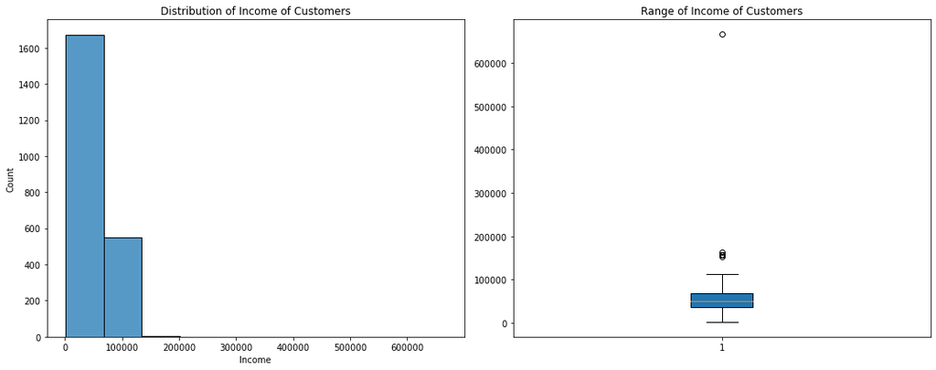

```python
fig, axes = plt.subplots(1,2,figsize=(15,6))
sb.histplot(df['Income'],bins=10,ax=axes[0])
plt.boxplot(df['Income'],patch_artist = True)
axes[0].set_title('Distribution of Income of Customers')
axes[1].set_title('Range of Income of Customers')
plt.tight_layout()
plt.show()
```

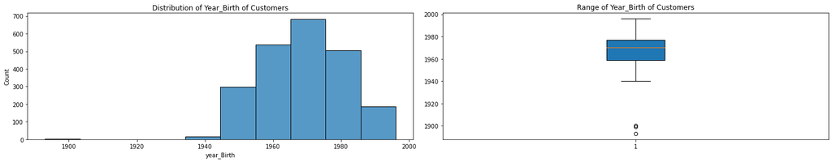

```python
fig, axes = plt.subplots(1,2, figsize=(20,4))

sb.histplot(df['year_Birth'],bins=10,ax=axes[0])
plt.boxplot(df['year_Birth'],patch_artist = True)

axes[0].set_title('Distribution of Year_Birth of Customers')
axes[1].set_title('Range of Year_Birth of Customers')
plt.tight_layout()
plt.show()
```

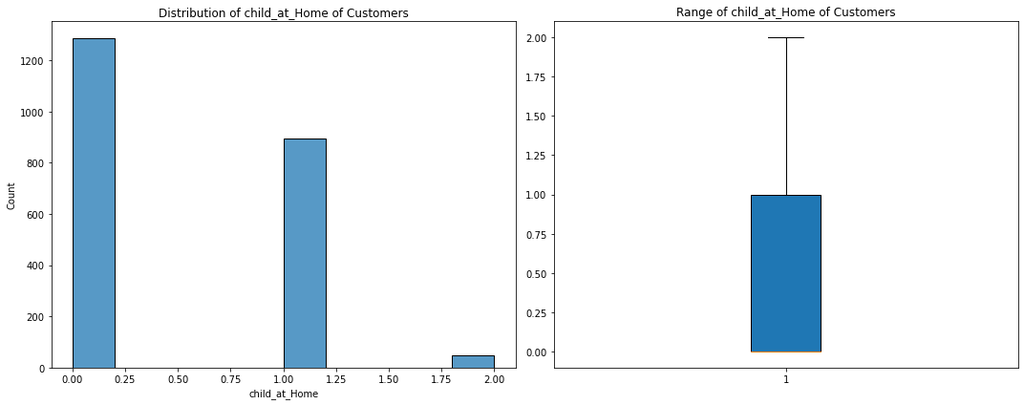

```python
fig, axes = plt.subplots(1,2, figsize=(15,6))
sb.histplot(df['child_at_Home'],bins=10,ax=axes[0])
plt.boxplot(df['child_at_Home'],patch_artist = True)

axes[0].set_title('Distribution of child_at_Home of Customers')
axes[1].set_title('Range of child_at_Home of Customers')
plt.tight_layout()
plt.show()
```

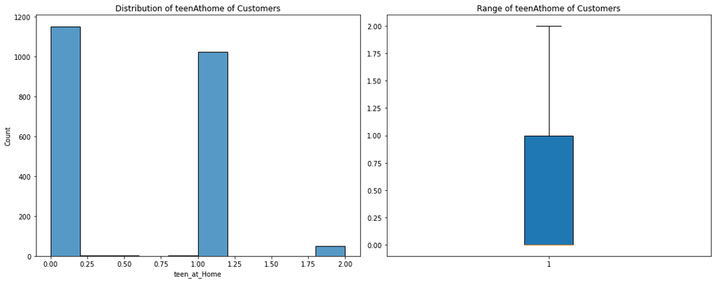

```python
fig, axes = plt.subplots(1,2, figsize=(15,6))

sb.histplot(df['teen_at_Home'],bins=10,ax=axes[0])
plt.boxplot(df['teen_at_Home'],patch_artist=True)

axes[0].set_title('Distribution of teenAthome of Customers')
axes[1].set_title('Range of teenAthome of Customers')
plt.tight_layout()
plt.show()
```

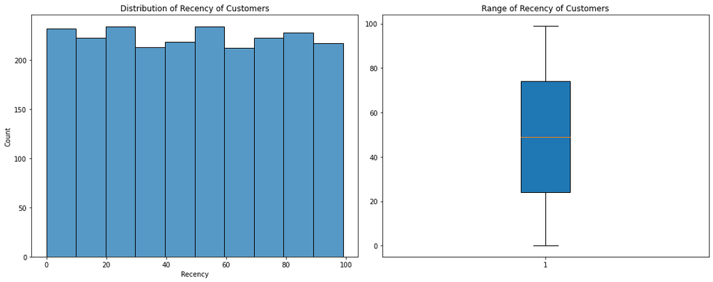

```python
fig, axes = plt.subplots(1,2, figsize=(15,6))

sb.histplot(df['Recency'],bins= 10,ax=axes[0])
plt.boxplot(df['Recency'],patch_artist=True)
axes[0].set_title('Distribution of Recency of Customers')
axes[1].set_title('Range of Recency of Customers')
plt.tight_layout()
plt.show()
```

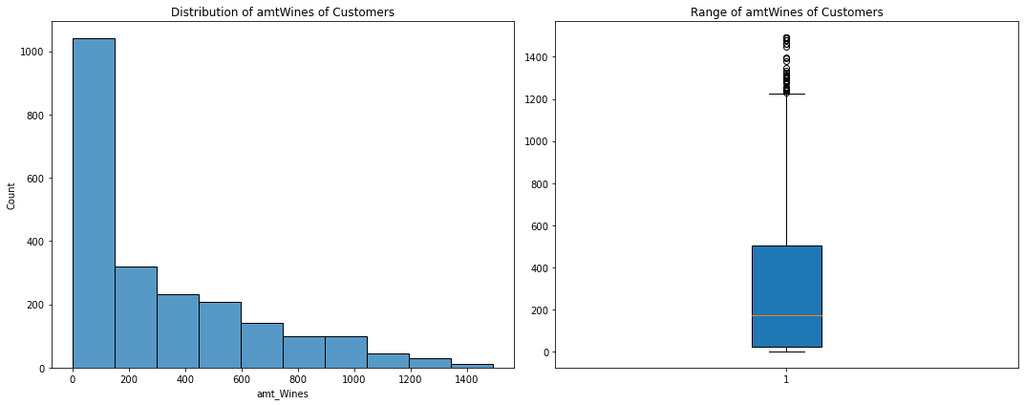

```python
fig, axes = plt.subplots(1,2, figsize=(15,6))

sb.histplot(df['amt_Wines'],bins= 10,ax=axes[0])


plt.boxplot(df['amt_Wines'],patch_artist=True)
axes[0].set_title('Distribution of amtWines of Customers')
axes[1].set_title('Range of amtWines of Customers')
plt.tight_layout()
plt.show()
```

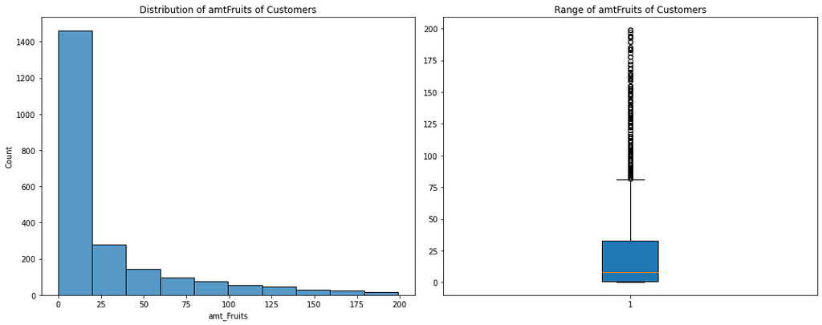

```python
fig, axes = plt.subplots(1,2, figsize=(15,6))

sb.histplot(df['amt_Fruits'],bins= 10,ax=axes[0])


plt.boxplot(df['amt_Fruits'],patch_artist=True)## Whiskers in the Boxplot shows that there are outliers
axes[0].set_title('Distribution of amtFruits of Customers')
axes[1].set_title('Range of amtFruits of Customers')
plt.tight_layout()
plt.show()
```

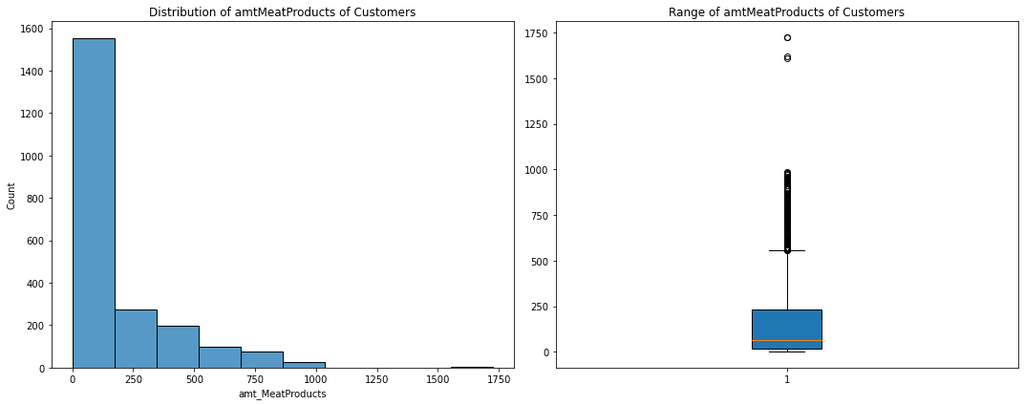

```python
fig, axes = plt.subplots(1,2, figsize=(15,6))

sb.histplot(df['amt_MeatProducts'],bins= 10,ax=axes[0])


plt.boxplot(df['amt_MeatProducts'],patch_artist=True)## Whiskers in the Boxplot shows that there are outliers
axes[0].set_title('Distribution of amtMeatProducts of Customers')
axes[1].set_title('Range of amtMeatProducts of Customers')
plt.tight_layout()
plt.show()
```

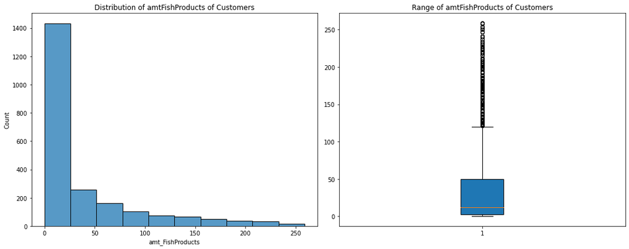

```python
fig, axes = plt.subplots(1,2, figsize=(15,6))

sb.histplot(df['amt_FishProducts'],bins= 10,ax=axes[0])


plt.boxplot(df['amt_FishProducts'],patch_artist=True)
axes[0].set_title('Distribution of amtFishProducts of Customers')
axes[1].set_title('Range of amtFishProducts of Customers')
plt.tight_layout()
plt.show()
```

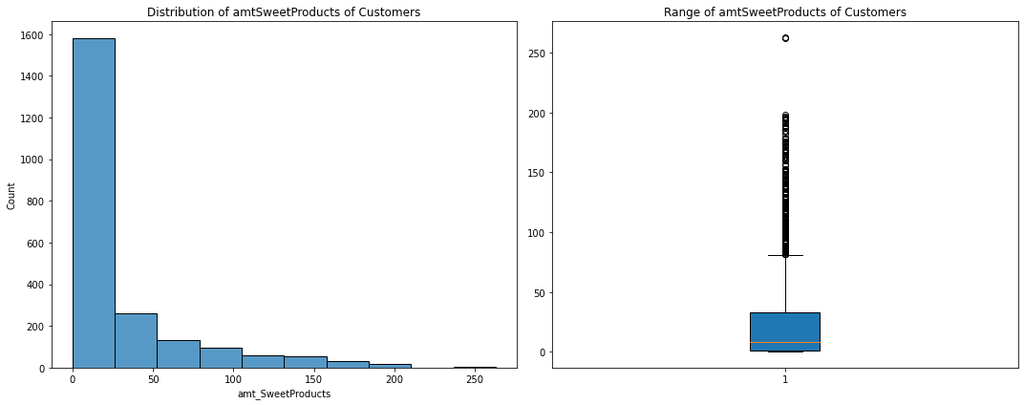

```python
fig, axes = plt.subplots(1,2, figsize=(15,6))

sb.histplot(df['amt_SweetProducts'],bins= 10,ax=axes[0])


plt.boxplot(df['amt_SweetProducts'],patch_artist=True)## Whiskers in the Boxplot shows that there are outliers
axes[0].set_title('Distribution of amtSweetProducts of Customers')
axes[1].set_title('Range of amtSweetProducts of Customers')
plt.tight_layout()
plt.show()
```

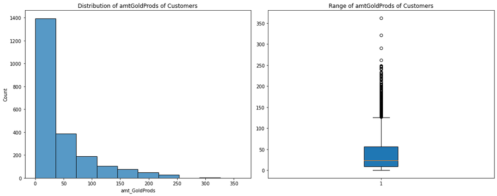

```python
fig, axes = plt.subplots(1,2, figsize=(15,6))

sb.histplot(df['amt_GoldProds'],bins= 10,ax=axes[0])


plt.boxplot(df['amt_GoldProds'],patch_artist=True)## Whiskers in the Boxplot shows that there are outliers
axes[0].set_title('Distribution of amtGoldProds of Customers')
axes[1].set_title('Range of amtGoldProds of Customers')
plt.tight_layout()
plt.show()
```

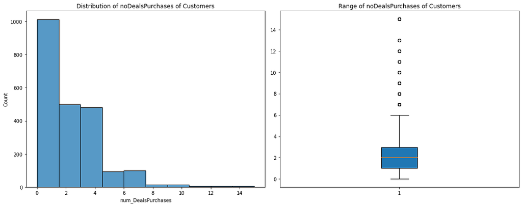

```python
fig, axes = plt.subplots(1,2, figsize=(15,6))

sb.histplot(df['num_DealsPurchases'],bins=10,ax=axes[0])


plt.boxplot(df['num_DealsPurchases'],patch_artist=True)## Whiskers in the Boxplot shows that there are outliers
axes[0].set_title('Distribution of noDealsPurchases of Customers')
axes[1].set_title('Range of noDealsPurchases of Customers')
plt.tight_layout()
plt.show()
```

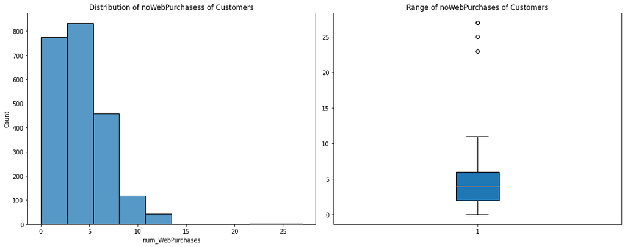

```python
fig, axes = plt.subplots(1,2, figsize=(15,6))

sb.histplot(df['num_WebPurchases'],bins=10,ax=axes[0])


plt.boxplot(df['num_WebPurchases'],patch_artist=True)
           ## Whiskers in the Boxplot shows that there are outliers
axes[0].set_title('Distribution of noWebPurchasess of Customers')
axes[1].set_title('Range of noWebPurchases of Customers')
plt.tight_layout()
plt.show()
```

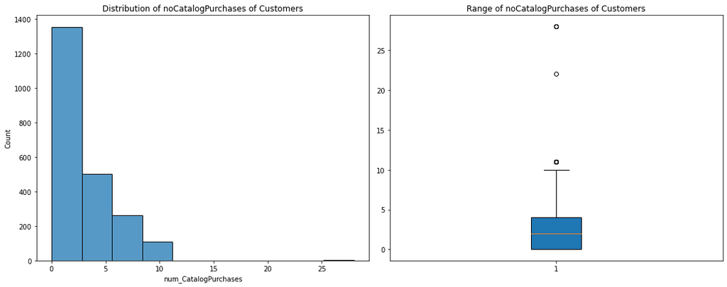

```python
fig, axes = plt.subplots(1,2, figsize=(15,6))

sb.histplot(df['num_CatalogPurchases'],bins= 10, ax=axes[0])


plt.boxplot(df['num_CatalogPurchases'],patch_artist=True)## Whiskers in the Boxplot shows that there are outliers
axes[0].set_title('Distribution of noCatalogPurchases of Customers')
axes[1].set_title('Range of noCatalogPurchases of Customers')
plt.tight_layout()
plt.show()
```

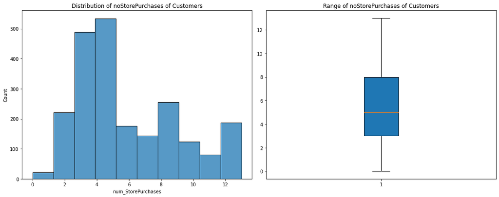

```python
fig, axes = plt.subplots(1,2, figsize=(15,6))

sb.histplot(df['num_StorePurchases'],bins= 10,ax=axes[0])


plt.boxplot(df['num_StorePurchases'],patch_artist=True)## Whiskers in the Boxplot shows that there are outliers
axes[0].set_title('Distribution of noStorePurchases of Customers')
axes[1].set_title('Range of noStorePurchases of Customers')
plt.tight_layout()
plt.show()
```

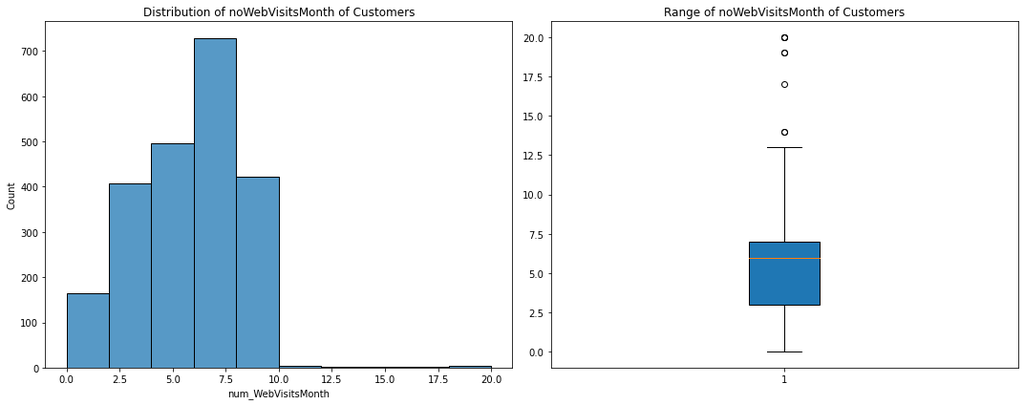

```python
fig, axes = plt.subplots(1,2, figsize=(15,6))

sb.histplot(df['num_WebVisitsMonth'],bins= 10,ax=axes[0])


plt.boxplot(df['num_WebVisitsMonth'],patch_artist=True)## Whiskers in the Boxplot shows that there are outliers
axes[0].set_title('Distribution of noWebVisitsMonth of Customers')
axes[1].set_title('Range of noWebVisitsMonth of Customers')
plt.tight_layout()
plt.show()
```

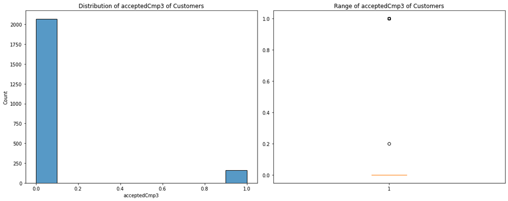

```python
fig, axes = plt.subplots(1,2, figsize=(15,6))

sb.histplot(df['acceptedCmp3'],bins= 10, ax=axes[0])


plt.boxplot(df['acceptedCmp3'],patch_artist=True)## Whiskers in the Boxplot shows that there are outliers
axes[0].set_title('Distribution of acceptedCmp3 of Customers')
axes[1].set_title('Range of acceptedCmp3 of Customers')
plt.tight_layout()
plt.show()
```

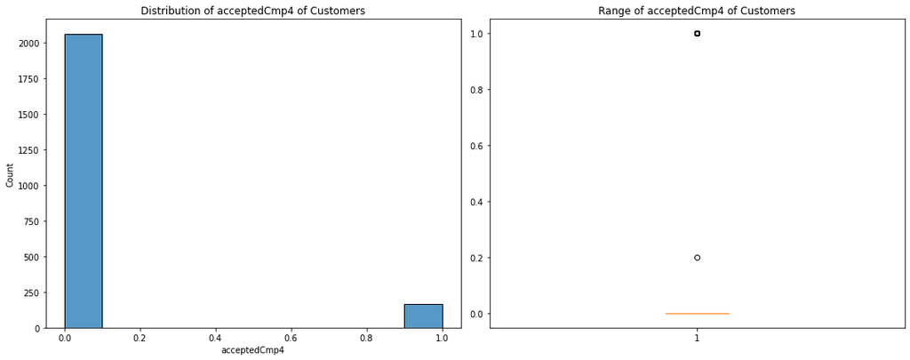

```python
fig, axes = plt.subplots(1,2, figsize=(15,6))

sb.histplot(df['acceptedCmp4'],bins= 10, ax=axes[0])


plt.boxplot(df['acceptedCmp4'])## Whiskers in the Boxplot shows that there are outliers
axes[0].set_title('Distribution of acceptedCmp4 of Customers')
axes[1].set_title('Range of acceptedCmp4 of Customers')
plt.tight_layout()
plt.show()
```

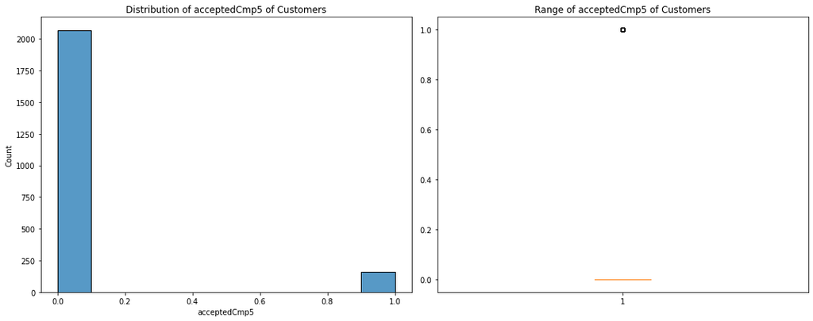

```python
fig, axes = plt.subplots(1,2, figsize=(15,6))

sb.histplot(df['acceptedCmp5'],bins= 10,ax=axes[0])


plt.boxplot(df['acceptedCmp5'])## Whiskers in the Boxplot shows that there are outliers
axes[0].set_title('Distribution of acceptedCmp5 of Customers')
axes[1].set_title('Range of acceptedCmp5 of Customers')
plt.tight_layout()
plt.show()
```

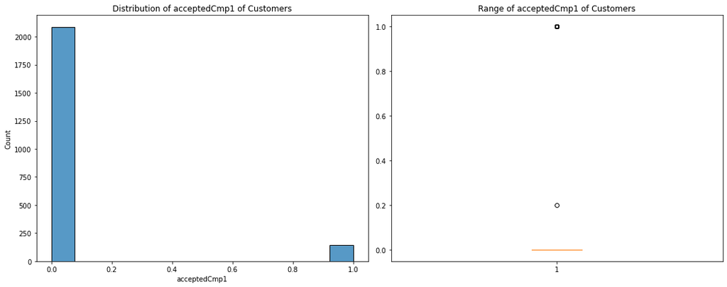

```python
fig, axes = plt.subplots(1,2, figsize=(15,6))

sb.histplot(df['acceptedCmp1'],ax=axes[0])


plt.boxplot(df['acceptedCmp1'])## Whiskers in the Boxplot shows that there are outliers
axes[0].set_title('Distribution of acceptedCmp1 of Customers')
axes[1].set_title('Range of acceptedCmp1 of Customers')
plt.tight_layout()
plt.show()
```

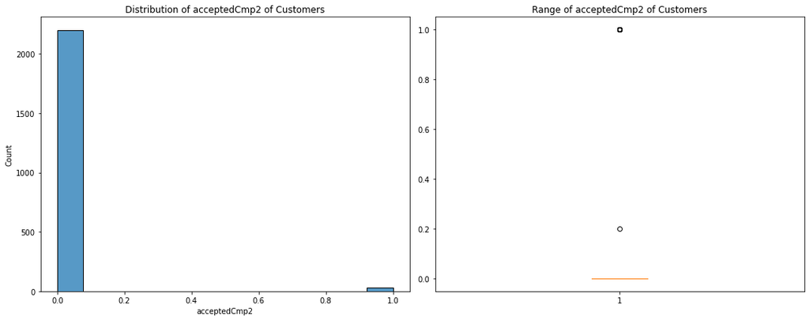

```python
fig, axes = plt.subplots(1,2, figsize=(15,6))

sb.histplot(df['acceptedCmp2'],ax=axes[0])


plt.boxplot(df['acceptedCmp2'])## Whiskers in the Boxplot shows that there are outliers
axes[0].set_title('Distribution of acceptedCmp2 of Customers')
axes[1].set_title('Range of acceptedCmp2 of Customers')
plt.tight_layout()
plt.show()
```

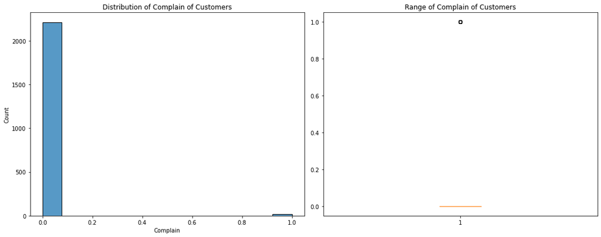

```python
fig, axes = plt.subplots(1,2, figsize=(15,6))

sb.histplot(df['Complain'],ax=axes[0])


plt.boxplot(df['Complain'])## Whiskers in the Boxplot shows that there are outliers
axes[0].set_title('Distribution of Complain of Customers')
axes[1].set_title('Range of Complain of Customers')
plt.tight_layout()
plt.show()
```

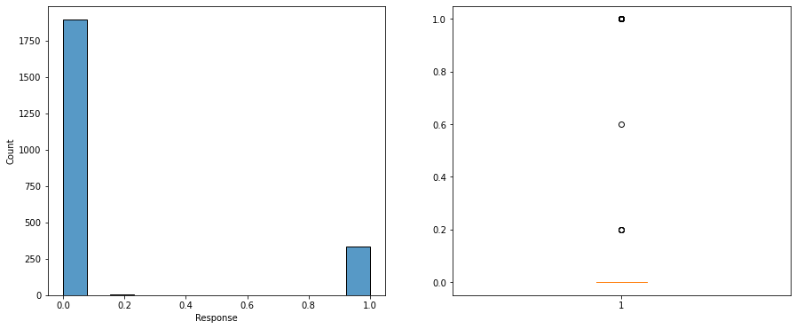

```python
fig, axes = plt.subplots(1,2, figsize=(15,6))



sb.histplot(df['Response'],ax=axes[0])
plt.boxplot(df['Response'])

plt.show()
```

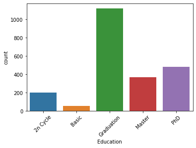

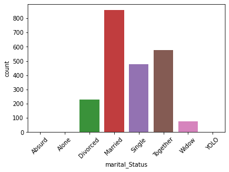

[figure not shown]

```python
for col in df:
    if pd.api.types.is_numeric_dtype(df[col]):
        print(" ")
    else:
        chart = sb.countplot(df[col]) # frequency distribution
        chart.set_xticklabels(chart.get_xticklabels(), rotation=45)
        plt.show()
```

```python
# correlation
subset = pd.DataFrame(df, columns= ['ID','Year_Birth','Education','Marital_Status','Income','childrenAtHome','teenAthome','dt_Customer','Recency','amtWines','amtFruits','amtMeatProducts','amtFishProducts','amtSweetProducts','amtGoldProds','noDealsPurchases','noWebPurchases','noCatalogPurchases','noStorePurchases','noWebVisitsMonth','acceptedCmp3','acceptedCmp4','acceptedCmp5','acceptedCmp1','acceptedCmp2','Complain','Response'])
```

```python
corr=subset.corr()
print(corr)
```

```
                          ID  Year_Birth  Marital_Status    Income  \
ID                  1.000000         NaN             NaN  0.015178
Year_Birth               NaN         NaN             NaN       NaN
Marital_Status           NaN         NaN             NaN       NaN
Income              0.015178         NaN             NaN  1.000000
childrenAtHome           NaN         NaN             NaN       NaN
teenAthome               NaN         NaN             NaN       NaN
Recency            -0.045849         NaN             NaN -0.003073
amtWines                 NaN         NaN             NaN       NaN
amtFruits                NaN         NaN             NaN       NaN
amtMeatProducts          NaN         NaN             NaN       NaN
amtFishProducts          NaN         NaN             NaN       NaN
amtSweetProducts         NaN         NaN             NaN       NaN
amtGoldProds             NaN         NaN             NaN       NaN
noDealsPurchases         NaN         NaN             NaN       NaN
noWebPurchases           NaN         NaN             NaN       NaN
noCatalogPurchases       NaN         NaN             NaN       NaN
noStorePurchases         NaN         NaN             NaN       NaN
noWebVisitsMonth         NaN         NaN             NaN       NaN
acceptedCmp3       -0.035082         NaN             NaN -0.017148
acceptedCmp4       -0.025650         NaN             NaN  0.184267
acceptedCmp5       -0.008109         NaN             NaN  0.337335
acceptedCmp1       -0.022201         NaN             NaN  0.276642
acceptedCmp2       -0.012974         NaN             NaN  0.089255
Complain            0.033749         NaN             NaN -0.027136
Response           -0.023917         NaN             NaN  0.135061

                    childrenAtHome  teenAthome   Recency  amtWines  amtFruits  \
ID                             NaN         NaN -0.045849       NaN        NaN
Year_Birth                     NaN         NaN       NaN       NaN        NaN
Marital_Status                 NaN         NaN       NaN       NaN        NaN
Income                         NaN         NaN -0.003073       NaN        NaN
childrenAtHome                 NaN         NaN       NaN       NaN        NaN
teenAthome                     NaN         NaN       NaN       NaN        NaN
Recency                        NaN         NaN  1.000000       NaN        NaN
amtWines                       NaN         NaN       NaN       NaN        NaN
amtFruits                      NaN         NaN       NaN       NaN        NaN
amtMeatProducts                NaN         NaN       NaN       NaN        NaN
amtFishProducts                NaN         NaN       NaN       NaN        NaN
amtSweetProducts               NaN         NaN       NaN       NaN        NaN
```

[output cut: 108 more lines]

```
amtGoldProds             NaN       NaN
noDealsPurchases         NaN       NaN
noWebPurchases           NaN       NaN
noCatalogPurchases       NaN       NaN
noStorePurchases         NaN       NaN
noWebVisitsMonth         NaN       NaN
acceptedCmp3        0.008670  0.248743
acceptedCmp4       -0.027747  0.175232
acceptedCmp5       -0.009518  0.325389
acceptedCmp1       -0.025628  0.292372
acceptedCmp2       -0.011252  0.173736
Complain            1.000000 -0.001784
Response           -0.001784  1.000000

[25 rows x 25 columns]
```

### Represting Heatmap

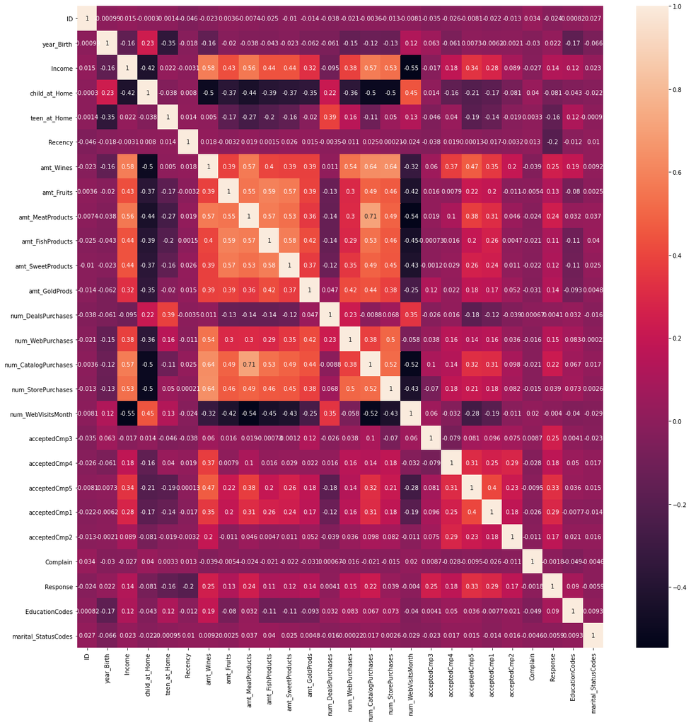

```python
plt.figure(figsize=(20,20))
sb.heatmap(df.corr(), annot=True)
plt.show()
```

## KNN

### train test split

```python
from sklearn.neighbors import KNeighborsClassifier
```

```python
from sklearn.model_selection import train_test_split
```

```python
dfX = dfnew[dfnew.columns[~dfnew.columns.isin(['Education','marital_Status', 'dt_Customer'])]]
dfY = df["Response"]
dfY = dfY.astype(int) # converting response variable to int other KNN will treat this as continuous
```

```python
X_train, X_test, y_train, y_test = train_test_split(dfX,dfY, test_size=0.2)
```

### Choosing k-value

```python
error_rate=[]
for i in range(1,50): # sqrt of rows is 47.3
    knn=KNeighborsClassifier(n_neighbors=i)
    knn.fit(X_train,y_train)
    pred=knn.predict(X_test)
    error_rate.append(np.mean(pred!=y_test))
```

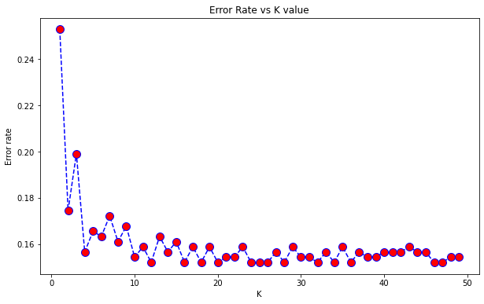

```python
plt.figure(figsize=(10,6))
plt.plot(range(1,50),error_rate,color='blue',linestyle='dashed',marker='o',markerfacecolor='red',markersize=10)
plt.title('Error Rate vs K value')
plt.xlabel('K')
plt.ylabel('Error rate')
```

### checking with k=10

```python
knn=KNeighborsClassifier(n_neighbors=10)
knn.fit(X_train,y_train)
pred_k=knn.predict(X_test)
pred_k
```

```
array([0, 0, 0, 0, 0, 0, 0, 0, 0, 0, 0, 0, 0, 0, 0, 0, 0, 0, 0, 0, 0, 1,
       0, 0, 0, 0, 0, 0, 0, 0, 0, 0, 0, 0, 0, 0, 0, 0, 0, 0, 0, 0, 0, 0,
       0, 0, 0, 0, 0, 0, 0, 0, 0, 0, 0, 0, 0, 0, 0, 0, 0, 0, 0, 0, 0, 0,
       0, 0, 0, 0, 0, 0, 0, 0, 0, 0, 0, 0, 0, 0, 0, 0, 0, 0, 0, 0, 0, 0,
       0, 0, 0, 0, 0, 0, 0, 0, 0, 0, 0, 0, 0, 0, 0, 0, 0, 0, 0, 0, 0, 0,
       0, 0, 0, 0, 0, 0, 0, 0, 0, 0, 0, 0, 0, 0, 0, 0, 0, 1, 0, 0, 0, 0,
       0, 0, 0, 0, 0, 0, 0, 0, 0, 0, 0, 0, 0, 0, 1, 0, 0, 0, 0, 0, 0, 0,
       0, 0, 0, 0, 0, 0, 0, 0, 0, 0, 0, 0, 0, 0, 0, 0, 0, 0, 0, 0, 0, 0,
       0, 0, 0, 0, 0, 0, 0, 0, 0, 0, 0, 0, 0, 0, 0, 0, 0, 0, 0, 0, 0, 1,
       0, 0, 0, 0, 0, 0, 0, 0, 0, 0, 0, 0, 0, 0, 0, 0, 0, 0, 0, 0, 0, 0,
       0, 0, 0, 0, 0, 0, 0, 0, 0, 0, 0, 0, 0, 0, 0, 0, 0, 0, 0, 0, 0, 0,
       0, 0, 0, 0, 0, 0, 0, 0, 0, 0, 0, 0, 0, 0, 1, 0, 0, 0, 0, 0, 0, 0,
       0, 0, 0, 0, 0, 0, 0, 1, 0, 1, 0, 0, 0, 0, 0, 0, 0, 0, 0, 0, 0, 0,
       0, 0, 0, 0, 0, 0, 0, 0, 0, 0, 0, 0, 0, 0, 0, 0, 0, 0, 0, 0, 0, 0,
       0, 0, 0, 0, 0, 0, 0, 0, 0, 0, 0, 0, 0, 0, 0, 0, 0, 0, 0, 0, 0, 0,
       0, 0, 0, 0, 0, 0, 0, 0, 0, 0, 0, 0, 0, 0, 0, 0, 0, 0, 0, 0, 0, 0,
       0, 0, 0, 0, 0, 0, 0, 0, 0, 0, 0, 0, 0, 0, 0, 0, 1, 0, 0, 0, 0, 0,
       0, 0, 0, 0, 0, 0, 0, 0, 1, 0, 0, 0, 0, 0, 0, 0, 0, 0, 0, 0, 0, 0,
       0, 1, 0, 0, 0, 0, 0, 0, 0, 0, 0, 0, 0, 0, 0, 0, 0, 0, 0, 0, 0, 0,
       0, 0, 0, 0, 0, 0, 0, 0, 0, 0, 0, 0, 0, 0, 0, 0, 0, 0, 0, 0, 0, 0,
       0, 0, 0, 0, 0, 0, 0])
```

```python
from sklearn.metrics import classification_report,confusion_matrix,accuracy_score
print(confusion_matrix(y_test,pred_k))
print(classification_report(y_test,pred_k))
print(accuracy_score(y_test,pred_k)*100)
```

```
[[374   6]
 [ 63   4]]
              precision    recall  f1-score   support

           0       0.86      0.98      0.92       380
           1       0.40      0.06      0.10        67

    accuracy                           0.85       447
   macro avg       0.63      0.52      0.51       447
weighted avg       0.79      0.85      0.79       447

84.56375838926175
```

### Decision tree

```python
df
```

|  | ID | year_Birth | Income | child_at_Home | teen_at_Home | Recency | amt_Wines | amt_Fruits | amt_MeatProducts | amt_FishProducts | ... | acceptedCmp5 | acceptedCmp1 | acceptedCmp2 | Complain | Response | EducationCodes | marital_StatusCodes | Education | marital_Status | dt_Customer |
| --- | --- | --- | --- | --- | --- | --- | --- | --- | --- | --- | --- | --- | --- | --- | --- | --- | --- | --- | --- | --- | --- |
| 0 | 5524.0 | 1957.0 | 58138.0 | 0.0 | 0.0 | 58.0 | 635.0 | 88.0 | 546.0 | 172.0 | ... | 0.0 | 0.0 | 0.0 | 0.0 | 1.0 | 2.0 | 4.0 | Graduation | Single | 2012-04-09 |
| 1 | 2174.0 | 1954.0 | 46344.0 | 1.0 | 1.0 | 38.0 | 11.0 | 1.0 | 6.0 | 2.0 | ... | 0.0 | 0.0 | 0.0 | 0.0 | 0.0 | 2.0 | 4.0 | Graduation | Single | 2014-08-03 |
| 2 | 4141.0 | 1965.0 | 71613.0 | 0.0 | 0.0 | 26.0 | 426.0 | 49.0 | 127.0 | 111.0 | ... | 0.0 | 0.0 | 0.0 | 0.0 | 0.0 | 2.0 | 5.0 | Graduation | Together | 2013-08-21 |
| 3 | 6182.0 | 1984.0 | 26646.0 | 1.0 | 0.0 | 26.0 | 11.0 | 4.0 | 20.0 | 10.0 | ... | 0.0 | 0.0 | 0.0 | 0.0 | 0.0 | 2.0 | 5.0 | Graduation | Together | 2014-10-02 |
| 4 | 5324.0 | 1981.0 | 58293.0 | 1.0 | 0.0 | 94.0 | 173.0 | 43.0 | 118.0 | 46.0 | ... | 0.0 | 0.0 | 0.0 | 0.0 | 0.0 | 4.0 | 3.0 | PhD | Married | 2014-01-19 |
| ... | ... | ... | ... | ... | ... | ... | ... | ... | ... | ... | ... | ... | ... | ... | ... | ... | ... | ... | ... | ... | ... |
| 2227 | 10870.0 | 1967.0 | 61223.0 | 0.0 | 1.0 | 46.0 | 709.0 | 43.0 | 182.0 | 42.0 | ... | 0.0 | 0.0 | 0.0 | 0.0 | 0.0 | 2.0 | 3.0 | Graduation | Married | 2013-03-03 |
| 2228 | 4001.0 | 1946.0 | 64014.0 | 2.0 | 1.0 | 56.0 | 406.0 | 0.0 | 30.0 | 0.0 | ... | 0.0 | 1.0 | 0.0 | 0.0 | 0.0 | 4.0 | 5.0 | PhD | Together | 2012-12-08 |
| 2229 | 7270.0 | 1981.0 | 56981.0 | 0.0 | 0.0 | 91.0 | 908.0 | 48.0 | 217.0 | 32.0 | ... | 0.0 | 0.0 | 0.0 | 0.0 | 0.0 | 2.0 | 2.0 | Graduation | Divorced | 2014-05-18 |
| 2230 | 8235.0 | 1956.0 | 69245.0 | 0.0 | 1.0 | 8.0 | 428.0 | 30.0 | 214.0 | 80.0 | ... | 0.0 | 0.0 | 0.0 | 0.0 | 0.0 | 3.0 | 5.0 | Master | Together | 2013-03-16 |
| 2231 | 9405.0 | 1954.0 | 52869.0 | 1.0 | 1.0 | 40.0 | 84.0 | 3.0 | 61.0 | 2.0 | ... | 0.0 | 0.0 | 0.0 | 0.0 | 1.0 | 4.0 | 3.0 | PhD | Married | 2012-08-21 |

2232 rows × 29 columns

```python
from sklearn import tree
from sklearn import metrics
from sklearn.tree import plot_tree


dfX=df[df.columns[~df.columns.isin(['Education','marital_Status','dt_Customer','Response'])]]

X_train, X_test, y_train, y_test = train_test_split(dfX,dfY, test_size=0.1)
# gini_impurity,defines the impurity in the dataset.
model=tree.DecisionTreeClassifier(max_depth=2)

d_tree_fit=model.fit(X_train,y_train)
```

```python
d_tree_predict=d_tree_fit.predict(X_test)
confusion_matrix(y_test,d_tree_predict)
print(classification_report(y_test,d_tree_predict))
print( metrics.accuracy_score(y_test,d_tree_predict)*100)
```

```
              precision    recall  f1-score   support

           0       0.88      0.99      0.94       196
           1       0.67      0.07      0.13        28

    accuracy                           0.88       224
   macro avg       0.77      0.53      0.53       224
weighted avg       0.86      0.88      0.83       224

87.94642857142857
```

### Plot the decision tree

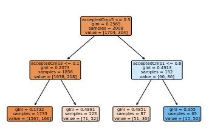

```python
dec_tree = plot_tree(decision_tree=d_tree_fit, feature_names = dfnew.columns,
                      filled = True , precision = 4, rounded = True)
```

### using entropy

```python
## criterion for selection measure.Entropy defines the degree of randomness.We always prefer to chose high information gain with low entropy.
d_tree_entropy=tree.DecisionTreeClassifier(criterion="entropy",max_depth=2)

## train decision tree classifier
d_tree_fit_entropy=d_tree_entropy.fit(X_train,y_train)

## predict with testing set
d_tree_predict=d_tree_fit_entropy.predict(X_test)

##check with the confusion ,matrix
confusion_matrix(y_test,d_tree_predict)
print(classification_report(y_test,d_tree_predict))

## check how often your selected classifier is correct
print("Accuracy : ", metrics.accuracy_score(y_test,d_tree_predict)*100)
```

```
              precision    recall  f1-score   support

           0       0.88      0.99      0.94       196
           1       0.67      0.07      0.13        28

    accuracy                           0.88       224
   macro avg       0.77      0.53      0.53       224
weighted avg       0.86      0.88      0.83       224

Accuracy :  87.94642857142857
```

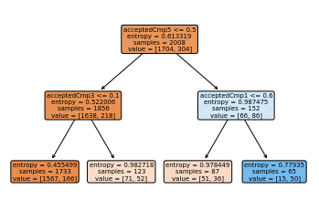

```python
dec_tree = plot_tree(decision_tree=d_tree_fit_entropy, feature_names = dfnew.columns,
                      filled = True , precision = 6, rounded = True)
```

### Logistic Regression

```python
# import sklearn.cross_validation from train_test_split
```

```python
#dfY = dfnew["Response"]
#dfY = dfY.astype(int)
#X_train,y_train,X_test,X_test=train_test_split(dfX,dfY,test_size=0.2)
```

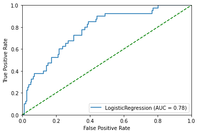

```python
from sklearn.linear_model import LogisticRegression
model=LogisticRegression()
model.fit(X_train,y_train)
metrics.plot_roc_curve(model, X_test, y_test)
plt.plot([0, 1], [0, 1],'g--')
plt.xlim([0.0, 1.0])
plt.ylim([0.0, 1.0])
plt.xlabel('False Positive Rate')
plt.ylabel('True Positive Rate')
plt.show()
```

```python
predict_logistic=model.predict(X_test)
```

```python
from sklearn import metrics
from sklearn.metrics import confusion_matrix,classification_report,accuracy_score
print(confusion_matrix(y_test,predict_logistic))
print(classification_report(y_test,predict_logistic))
print(accuracy_score(y_test,predict_logistic)*100)
```

```
[[179   5]
 [ 33   7]]
              precision    recall  f1-score   support

           0       0.84      0.97      0.90       184
           1       0.58      0.17      0.27        40

    accuracy                           0.83       224
   macro avg       0.71      0.57      0.59       224
weighted avg       0.80      0.83      0.79       224

83.03571428571429
```

### K-Means Clustering

```python
from sklearn.cluster import KMeans
```

```python
#dfX = dfnew[dfnew.columns[~dfnew.columns.isin(['Education','Marital_Status', 'Dt_Customer'])]]
data=df[df.columns[~df.columns.isin(['Education','marital_Status','dt_Customer'])]]
```

```python
kmeans=KMeans(n_clusters=3,init='random',n_init=10,max_iter=200,random_state=34)
kmeans
kmeans.fit(data)
cluster_means=kmeans.predict(data)
print("SSE Value:",kmeans.inertia_)    #  defines the lowest SSE Value. SSE is a sum of squared error which always need to minimum .
print("location of centroid :", kmeans.cluster_centers_)   # sepecifies the location of centroid
```

```
SSE Value: 545237019860.80695
location of centroid : [[ 5.71072596e+03  1.96771218e+03  7.89224439e+04  8.33333333e-02
   3.26923077e-01  4.94605769e+01  6.32229167e+02  5.92564103e+01
   4.11377885e+02  8.53573718e+01  6.25528846e+01  7.16987179e+01
   1.53717949e+00  5.35993590e+00  5.56730769e+00  8.38685897e+00
   3.06891026e+00  7.05128205e-02  1.36217949e-01  2.46794872e-01
   1.97435897e-01  2.56410256e-02  4.80769231e-03  2.48076923e-01
   2.46314103e+00  3.74198718e+00]
 [ 5.60932917e+03  1.97289010e+03  2.88287188e+04  8.02604167e-01
   3.30468750e-01  4.86263021e+01  3.32742187e+01  6.08151042e+00
   2.60460938e+01  9.30572917e+00  6.18098958e+00  1.81393229e+01
   2.15781250e+00  2.19531250e+00  5.47135417e-01  3.10520833e+00
   6.88593750e+00  8.59375000e-02  5.20833333e-03  9.71445147e-17
   1.30208333e-03 -6.93889390e-18  1.69270833e-02  1.13541667e-01
   2.17968750e+00  3.70052083e+00]
 [ 5.50608571e+03  1.96586119e+03  5.36826488e+04  3.84523810e-01
   7.98095238e-01  4.92892857e+01  3.08980714e+02  2.05150000e+01
   1.13394048e+02  2.79464286e+01  1.97095238e+01  4.69711905e+01
   3.05000000e+00  4.85976190e+00  2.43928571e+00  6.31785714e+00
   5.54095238e+00  6.09523810e-02  9.30952381e-02  1.07142857e-02
   2.38095238e-02  1.57142857e-02  5.95238095e-03  1.08809524e-01
   2.50833333e+00  3.71904762e+00]]
```

### Choosing appropriate number of clusters

### Elbow Method

```python
kmeans_func={
    "init":"random",
    "n_init":10,
    "max_iter":200,
    "random_state":42
}

sse=[]

for k in range(1,10):
    kmeans_optimal=KMeans(n_clusters=k,**kmeans_func) ## here ** is a dictionary unpacking operator.
    kmeans_optimal.fit(data)
    sse.append(kmeans_optimal.inertia_)
```

```python
kmeans_optimal.inertia_
```

```
54500707394.121376
```

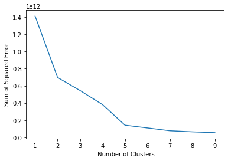

```python
plt.plot(range(1,10),sse)
plt.xlabel(" Number of Clusters")
plt.ylabel("Sum of Squared Error")
plt.show()
```

### here we are not able to figure out which k value is appropriate so for that kneed function is use to get the k value from this plot

### Kneed

```python
!pip install --upgrade kneed
```

```python
from kneed import KneeLocator, DataGenerator
```

```python
k=KneeLocator(range(1,10),sse,curve="convex",direction="decreasing")
k.elbow
```

```
5
```

```python
kmeans=KMeans(n_clusters=5,init='random',n_init=10,max_iter=200,random_state=34)
kmeans
kmeans.fit(data)
cluster_means=kmeans.predict(data)
print("SSE Value:",kmeans.inertia_)    #  defines the lowest SSE Value. SSE is a sum of squared error which always need to minimum .
print("location of centroid :", kmeans.cluster_centers_)   # sepecifies the location of centroid
```

```
SSE Value: 141604120537.50497
location of centroid : [[ 5.60952538e+03  1.96782335e+03  8.27833477e+04  7.36040609e-02
   2.39593909e-01  5.01131980e+01  6.60468020e+02  6.52578680e+01
   4.64928426e+02  9.20558376e+01  6.77329949e+01  7.11421320e+01
   1.23857868e+00  5.27664975e+00  5.99340102e+00  8.26497462e+00
   2.67512690e+00  9.39086294e-02  1.57360406e-01  3.50253807e-01
   2.69543147e-01  3.55329949e-02  5.07614213e-03  3.16243655e-01
   2.44923858e+00  3.76142132e+00]
 [ 5.38652547e+03  1.96824374e+03  4.35778432e+04  6.43165468e-01
   6.69352518e-01  5.01741007e+01  1.39128345e+02  9.12287770e+00
   5.74402878e+01  1.47335252e+01  1.01536691e+01  3.07482014e+01
   2.76028777e+00  3.44431655e+00  1.30359712e+00  4.32546763e+00
   6.28201439e+00  8.37410072e-02  4.34532374e-02  2.87769784e-03
   1.00719424e-02  5.75539568e-03  1.29496403e-02  1.21438849e-01
   2.49928058e+00  3.73381295e+00]
 [ 5.75146197e+03  1.97412032e+03  2.41387364e+04  7.91549296e-01
   2.25352113e-01  4.80623742e+01  1.93810865e+01  5.82052314e+00
   2.18981891e+01  8.40040241e+00  5.83299799e+00  1.65372233e+01
   2.02655936e+00  1.98672032e+00  4.59154930e-01  2.94366197e+00
   7.03098592e+00  8.04828974e-02  2.01207243e-03  8.32667268e-17
  -6.93889390e-17 -1.21430643e-17  1.00603622e-02  9.89939638e-02
   1.99597586e+00  3.71629779e+00]
 [ 9.43200000e+03  1.97700000e+03  6.66666000e+05  1.00000000e+00
   0.00000000e+00  2.30000000e+01  9.00000000e+00  1.40000000e+01
   1.80000000e+01  8.00000000e+00  1.00000000e+00  1.20000000e+01
   4.00000000e+00  3.00000000e+00  1.00000000e+00  3.00000000e+00
   6.00000000e+00  0.00000000e+00  0.00000000e+00  0.00000000e+00
   0.00000000e+00  0.00000000e+00  0.00000000e+00  0.00000000e+00
   2.00000000e+00  5.00000000e+00]
 [ 5.69747752e+03  1.96587411e+03  6.34335318e+04  1.87596899e-01
   7.07906977e-01  4.81950388e+01  4.85347907e+02  3.70858915e+01
   2.13875969e+02  5.14604651e+01  3.67324031e+01  6.27841860e+01
   2.72992248e+00  5.65829457e+00  3.79317829e+00  8.05674419e+00
   4.55410853e+00  4.03100775e-02  1.14728682e-01  3.56589147e-02
   4.80620155e-02  1.73643411e-02  7.75193798e-03  1.16589147e-01
   2.51472868e+00  3.67751938e+00]]
```

```python
df.iloc[1,]
```

```
ID                                     2174
year_Birth                             1954
Income                                46344
child_at_Home                             1
teen_at_Home                              1
Recency                                  38
amt_Wines                                11
amt_Fruits                                1
amt_MeatProducts                          6
amt_FishProducts                          2
amt_SweetProducts                         1
amt_GoldProds                             6
num_DealsPurchases                        2
num_WebPurchases                          1
num_CatalogPurchases                      1
num_StorePurchases                        2
num_WebVisitsMonth                        5
acceptedCmp3                              0
acceptedCmp4                              0
acceptedCmp5                              0
acceptedCmp1                              0
acceptedCmp2                              0
Complain                                  0
Response                                  0
EducationCodes                            2
marital_StatusCodes                       4
Education                        Graduation
marital_Status                       Single
dt_Customer             2014-08-03 00:00:00
Name: 1, dtype: object
```

```python
df['cluster_no'] = kmeans.labels_
```

```python
df
```

|  | ID | year_Birth | Income | child_at_Home | teen_at_Home | Recency | amt_Wines | amt_Fruits | amt_MeatProducts | amt_FishProducts | ... | acceptedCmp1 | acceptedCmp2 | Complain | Response | EducationCodes | marital_StatusCodes | Education | marital_Status | dt_Customer | cluster_no |
| --- | --- | --- | --- | --- | --- | --- | --- | --- | --- | --- | --- | --- | --- | --- | --- | --- | --- | --- | --- | --- | --- |
| 0 | 5524.0 | 1957.0 | 58138.0 | 0.0 | 0.0 | 58.0 | 635.0 | 88.0 | 546.0 | 172.0 | ... | 0.0 | 0.0 | 0.0 | 1.0 | 2.0 | 4.0 | Graduation | Single | 2012-04-09 | 4 |
| 1 | 2174.0 | 1954.0 | 46344.0 | 1.0 | 1.0 | 38.0 | 11.0 | 1.0 | 6.0 | 2.0 | ... | 0.0 | 0.0 | 0.0 | 0.0 | 2.0 | 4.0 | Graduation | Single | 2014-08-03 | 1 |
| 2 | 4141.0 | 1965.0 | 71613.0 | 0.0 | 0.0 | 26.0 | 426.0 | 49.0 | 127.0 | 111.0 | ... | 0.0 | 0.0 | 0.0 | 0.0 | 2.0 | 5.0 | Graduation | Together | 2013-08-21 | 4 |
| 3 | 6182.0 | 1984.0 | 26646.0 | 1.0 | 0.0 | 26.0 | 11.0 | 4.0 | 20.0 | 10.0 | ... | 0.0 | 0.0 | 0.0 | 0.0 | 2.0 | 5.0 | Graduation | Together | 2014-10-02 | 2 |
| 4 | 5324.0 | 1981.0 | 58293.0 | 1.0 | 0.0 | 94.0 | 173.0 | 43.0 | 118.0 | 46.0 | ... | 0.0 | 0.0 | 0.0 | 0.0 | 4.0 | 3.0 | PhD | Married | 2014-01-19 | 4 |
| ... | ... | ... | ... | ... | ... | ... | ... | ... | ... | ... | ... | ... | ... | ... | ... | ... | ... | ... | ... | ... | ... |
| 2227 | 10870.0 | 1967.0 | 61223.0 | 0.0 | 1.0 | 46.0 | 709.0 | 43.0 | 182.0 | 42.0 | ... | 0.0 | 0.0 | 0.0 | 0.0 | 2.0 | 3.0 | Graduation | Married | 2013-03-03 | 4 |
| 2228 | 4001.0 | 1946.0 | 64014.0 | 2.0 | 1.0 | 56.0 | 406.0 | 0.0 | 30.0 | 0.0 | ... | 1.0 | 0.0 | 0.0 | 0.0 | 4.0 | 5.0 | PhD | Together | 2012-12-08 | 4 |
| 2229 | 7270.0 | 1981.0 | 56981.0 | 0.0 | 0.0 | 91.0 | 908.0 | 48.0 | 217.0 | 32.0 | ... | 0.0 | 0.0 | 0.0 | 0.0 | 2.0 | 2.0 | Graduation | Divorced | 2014-05-18 | 4 |
| 2230 | 8235.0 | 1956.0 | 69245.0 | 0.0 | 1.0 | 8.0 | 428.0 | 30.0 | 214.0 | 80.0 | ... | 0.0 | 0.0 | 0.0 | 0.0 | 3.0 | 5.0 | Master | Together | 2013-03-16 | 4 |
| 2231 | 9405.0 | 1954.0 | 52869.0 | 1.0 | 1.0 | 40.0 | 84.0 | 3.0 | 61.0 | 2.0 | ... | 0.0 | 0.0 | 0.0 | 1.0 | 4.0 | 3.0 | PhD | Married | 2012-08-21 | 1 |

2232 rows × 30 columns

```python
[i for i in range(1,6)]
```

```
[1, 2, 3, 4, 5]
```

```python
for x in range(1, 6):
    globals()['df%s' % x] = df[df['cluster_no'] == x]
```

```python
df1
```

|  | ID | year_Birth | Income | child_at_Home | teen_at_Home | Recency | amt_Wines | amt_Fruits | amt_MeatProducts | amt_FishProducts | ... | acceptedCmp1 | acceptedCmp2 | Complain | Response | EducationCodes | marital_StatusCodes | Education | marital_Status | dt_Customer | cluster_no |
| --- | --- | --- | --- | --- | --- | --- | --- | --- | --- | --- | --- | --- | --- | --- | --- | --- | --- | --- | --- | --- | --- |
| 1 | 2174.0 | 1954.0 | 46344.0 | 1.0 | 1.0 | 38.0 | 11.0 | 1.0 | 6.0 | 2.0 | ... | 0.0 | 0.0 | 0.0 | 0.0 | 2.0 | 4.0 | Graduation | Single | 2014-08-03 | 1 |
| 10 | 1994.0 | 1983.0 | 51369.0 | 1.0 | 0.0 | 11.0 | 5.0 | 5.0 | 6.0 | 0.0 | ... | 0.0 | 0.0 | 0.0 | 0.0 | 2.0 | 3.0 | Graduation | Married | 2013-11-15 | 1 |
| 16 | 9736.0 | 1980.0 | 41850.0 | 1.0 | 1.0 | 51.0 | 53.0 | 5.0 | 19.0 | 2.0 | ... | 0.0 | 0.0 | 0.0 | 0.0 | 2.0 | 3.0 | Graduation | Married | 2012-12-24 | 1 |
| 17 | 4939.0 | 1946.0 | 37760.0 | 0.0 | 0.0 | 20.0 | 84.0 | 5.0 | 38.0 | 150.0 | ... | 0.0 | 0.0 | 0.0 | 0.0 | 2.0 | 5.0 | Graduation | Together | 2012-08-31 | 1 |
| 19 | 2278.0 | 1985.0 | 33812.0 | 1.0 | 0.0 | 86.0 | 4.0 | 17.0 | 19.0 | 30.0 | ... | 0.0 | 0.0 | 0.0 | 0.0 | 0.0 | 4.0 | 2n Cycle | Single | 2012-03-11 | 1 |
| ... | ... | ... | ... | ... | ... | ... | ... | ... | ... | ... | ... | ... | ... | ... | ... | ... | ... | ... | ... | ... | ... |
| 2211 | 9246.0 | 1985.0 | 40101.0 | 1.0 | 0.0 | 73.0 | 171.0 | 3.0 | 129.0 | 26.0 | ... | 0.0 | 0.0 | 0.0 | 0.0 | 3.0 | 5.0 | Master | Together | 2014-05-02 | 1 |
| 2220 | 8720.0 | 1963.6 | 51369.0 | 0.0 | 0.0 | 53.0 | 32.0 | 2.0 | 1607.0 | 12.0 | ... | 0.0 | 0.0 | 0.0 | 0.0 | 0.0 | 5.0 | 2n Cycle | Together | 2013-11-26 | 1 |
| 2223 | 9817.0 | 1970.0 | 44802.0 | 0.0 | 0.0 | 71.0 | 853.0 | 10.0 | 143.0 | 13.0 | ... | 0.0 | 0.0 | 0.0 | 0.0 | 3.0 | 4.0 | Master | Single | 2014-06-25 | 1 |
| 2226 | 8372.0 | 1974.0 | 34421.0 | 1.0 | 0.0 | 81.0 | 3.0 | 3.0 | 7.0 | 6.0 | ... | 0.0 | 0.0 | 0.0 | 0.0 | 2.0 | 3.0 | Graduation | Married | 2013-03-24 | 1 |
| 2231 | 9405.0 | 1954.0 | 52869.0 | 1.0 | 1.0 | 40.0 | 84.0 | 3.0 | 61.0 | 2.0 | ... | 0.0 | 0.0 | 0.0 | 1.0 | 4.0 | 3.0 | PhD | Married | 2012-08-21 | 1 |

695 rows × 30 columns

### so here we have got k as 5 that represent appropriate valur for number of clusters is 5.